# Notebook_Exploration_Analysis

Lei Yue

2025-05-13

## intall library

```r
rm(list = ls())

if (!require("pacman")) install.packages("pacman")
```

```r
p_load("tidyverse","ggplot2","ggwordcloud",
       "ggrepel","xlsx","patchwork",
       "sf","ggspatial","pcutils","igraph",
       "MetaNet","here","correlation")
```

```
##
##  C:\Users\yuelei\AppData\Local\Temp\RtmpOs6Acj\downloaded_packages
```

```
##
## xlsx installed
```

Load the process data of the main analysis by running an R script

```r
## main analyze Rmd data
source("Notebook_Data_Analysis_CHN_Sample_Stage2_RR_V2.R")
```

```
## Skipping 'BTS_Atari_et_al_2020' because it does not contain a 'Age' column.
```

```
## Skipping 'BTS_Atari_et_al_2020' because it does not contain a 'Age' column.
## Skipping 'BTS_Atari_et_al_2020' because it does not contain a 'Age' column.
```

```
## `summarise()` has regrouped the output.
## `summarise()` has regrouped the output.
## `summarise()` has regrouped the output.
## `summarise()` has regrouped the output.
```

## Check articles num in different journals

```r
Journal_check <- Journal %>%
  dplyr::select(Article_IDs_N) %>%
  dplyr::distinct(Article_IDs_N) %>%
  dplyr::mutate(Year = substr(Article_IDs_N,1,4),
                Journal = substr(Article_IDs_N,5,5)) %>%
  dplyr::group_by(Year,Journal) %>%
  dplyr::summarise(n = n()) %>%
  dplyr::ungroup()
```

```
## `summarise()` has regrouped the output.
## ℹ Summaries were computed grouped by Year and Journal.
## ℹ Output is grouped by Year.
## ℹ Use `summarise(.groups = "drop_last")` to silence this message.
## ℹ Use `summarise(.by = c(Year, Journal))` for per-operation grouping
##   (`?dplyr::dplyr_by`) instead.
```

```r
Journal_check
```

```
## # A tibble: 15 × 3
##    Year  Journal     n
##    <chr> <chr>   <int>
##  1 2008  1          39
##  2 2008  2         107
##  3 2008  3          64
##  4 2008  4          24
##  5 2008  5          16
##  6 2018  1          97
##  7 2018  2         115
##  8 2018  3         146
##  9 2018  4          61
## 10 2018  5          81
## 11 2021  1          28
## 12 2021  2          61
## 13 2021  3          94
## 14 2021  4          29
## 15 2021  5          38
```

## Journal report in different period

2008

```r
Journal_year2008_report <- Journal %>%
  dplyr::filter(substr(Article_IDs_N,1,4) == "2008") %>%
  dplyr::mutate(Subjects_Recruitment_Area = ifelse(Subjects_Recruitment_Area == 0, 0, 1),
                Sampling_Method = ifelse(Sampling_Method == 0, 0 ,1),
                SES_N = ifelse(SES_N == 0, 0, 1),
                Subjects_Recruitment_Method_N = ifelse(Subjects_Recruitment_Method_N == 0, 0, 1)) %>%
  dplyr::group_by(Article_IDs,Study_Number) %>%
  dplyr::summarise(Age = max(Age) > 0,
                   Gender = max(Gender) > 0,
                   Religious = max(Religious) > 0,
                   Ethnicity = max(Ethnicity) > 0,
                   Sampling_Method = max(Sampling_Method) > 0,
                   Recruitment_Area = max(Subjects_Recruitment_Area) > 0,
                   Recruitment_Method = max(Subjects_Recruitment_Method_N) > 0,
                   SES = max(SES_N) > 0,
                   .groups = "drop") %>%
  dplyr::select(3:last_col())


report_list <- list()

for (i in names(Journal_year2008_report )){


  report_table <- data.frame(table(Journal_year2008_report [[i]])) %>%
    dplyr::mutate(col_names = names(Journal_year2008_report [i]),
                  proportion = Freq / sum(Freq))

  report_list[[i]] <- report_table

}

Journal_year2008_report <- do.call(rbind, report_list) %>%
  dplyr::mutate(Var1 = ifelse(Var1 == "TRUE", "Reported","Unreported"))


### Calculate reported status of Educational_Attainment and Occupation
Journal_year2008_education_occupation <- Journal %>%
  dplyr::filter(substr(Article_IDs_N,1,4) == "2008") %>%
  dplyr::filter(Sample_Type_N %in% c(4,5)) %>%
  dplyr::group_by(Article_IDs,Study_Number) %>%
  dplyr::summarise(Educational_Attainment_N = max(Educational_Attainment_N) > 0,
                   Occupation_N = max(Occupation_N) > 0,.groups = "drop")



table(Journal_year2008_education_occupation$Educational_Attainment_N)
```

```
##
## FALSE  TRUE
##    34    31
```

```r
table(Journal_year2008_education_occupation$Occupation_N)
```

```
##
## FALSE  TRUE
##    36    29
```

```r
Journal_year2008_education_occupation_table <- data.frame(Var1 = c("Unreported","Reported",
                                                            "Unreported","Reported"),
                                                   Freq = c(34,31,36,29),
                                                   col_names= c("Educational_Attainment",
                                                                "Educational_Attainment",
                                                                "Occupation","Occupation"),
                                                   proportion = c(34/(34+31),31/(34+31),
                                                                  36/(36+29),29/(36+29)))

Journal_year2008_report2 <- rbind(Journal_year2008_report,
                                  Journal_year2008_education_occupation_table) %>%
  dplyr::mutate(col_names = factor(col_names,
                                   labels = c("Gender","Recruitment Method",
                                              "Recruitment Area",
                                              "Age","Educational Attainment",
                                              "Occupation","Sampling Method",
                                              "SES","Ethnicity","Religious"),
                                   levels = c("Gender","Recruitment_Method",
                                              "Recruitment_Area",
                                              "Age","Educational_Attainment",
                                              "Occupation","Sampling_Method",
                                              "SES","Ethnicity","Religious")),
                proportion = proportion *100) %>%
  dplyr::mutate(Year = "2008")
```

2018

```r
Journal_year2018_report <- Journal %>%
  dplyr::filter(substr(Article_IDs_N,1,4) == "2018") %>%
  dplyr::mutate(Subjects_Recruitment_Area = ifelse(Subjects_Recruitment_Area == 0, 0, 1),
                Sampling_Method = ifelse(Sampling_Method == 0, 0 ,1),
                SES_N = ifelse(SES_N == 0, 0, 1),
                Subjects_Recruitment_Method_N = ifelse(Subjects_Recruitment_Method_N == 0, 0, 1)) %>%
  dplyr::group_by(Article_IDs,Study_Number) %>%
  dplyr::summarise(Age = max(Age) > 0,
                   Gender = max(Gender) > 0,
                   Religious = max(Religious) > 0,
                   Ethnicity = max(Ethnicity) > 0,
                   Sampling_Method = max(Sampling_Method) > 0,
                   Recruitment_Area = max(Subjects_Recruitment_Area) > 0,
                   Recruitment_Method = max(Subjects_Recruitment_Method_N) > 0,
                   SES = max(SES_N) > 0,
                   .groups = "drop") %>%
  dplyr::select(3:last_col())


report_list <- list()

for (i in names(Journal_year2018_report )){


  report_table <- data.frame(table(Journal_year2018_report [[i]])) %>%
    dplyr::mutate(col_names = names(Journal_year2018_report [i]),
                  proportion = Freq / sum(Freq))

  report_list[[i]] <- report_table

}

Journal_year2018_report <- do.call(rbind, report_list) %>%
  dplyr::mutate(Var1 = ifelse(Var1 == "TRUE", "Reported","Unreported"))


### Calculate reported status of Educational_Attainment and Occupation
Journal_year2018_education_occupation <- Journal %>%
  dplyr::filter(substr(Article_IDs_N,1,4) == "2018") %>%
  dplyr::filter(Sample_Type_N %in% c(4,5)) %>%
  dplyr::group_by(Article_IDs,Study_Number) %>%
  dplyr::summarise(Educational_Attainment_N = max(Educational_Attainment_N) > 0,
                   Occupation_N = max(Occupation_N) > 0,.groups = "drop")



table(Journal_year2018_education_occupation$Educational_Attainment_N)
```

```
##
## FALSE  TRUE
##    74    75
```

```r
table(Journal_year2018_education_occupation$Occupation_N)
```

```
##
## FALSE  TRUE
##    90    59
```

```r
Journal_year2018_education_occupation_table <- data.frame(Var1 = c("Unreported","Reported",
                                                            "Unreported","Reported"),
                                                   Freq = c(74,75,90,59),
                                                   col_names= c("Educational_Attainment",
                                                                "Educational_Attainment",
                                                                "Occupation","Occupation"),
                                                   proportion = c(74/(74+75),75/(74+75),
                                                                  90/(90+59),59/(90+59)))

Journal_year2018_report2 <- rbind(Journal_year2018_report,
                                  Journal_year2018_education_occupation_table) %>%
  dplyr::mutate(col_names = factor(col_names,
                                   labels = c("Gender","Age","Recruitment Method",
                                              "Recruitment Area",
                                              "Educational Attainment",
                                              "Occupation","Sampling Method",
                                              "SES","Ethnicity","Religious"),
                                   levels = c("Gender","Age","Recruitment_Method",
                                              "Recruitment_Area",
                                              "Educational_Attainment",
                                              "Occupation","Sampling_Method",
                                              "SES","Ethnicity","Religious")),
                proportion = proportion *100)%>%
  dplyr::mutate(Year = "2018")
```

2020-2021

```r
Journal_year2021_report <- Journal %>%
  dplyr::filter(substr(Article_IDs_N,1,4) == "2021") %>%
  dplyr::mutate(Subjects_Recruitment_Area = ifelse(Subjects_Recruitment_Area == 0, 0, 1),
                Sampling_Method = ifelse(Sampling_Method == 0, 0 ,1),
                SES_N = ifelse(SES_N == 0, 0, 1),
                Subjects_Recruitment_Method_N = ifelse(Subjects_Recruitment_Method_N == 0, 0, 1)) %>%
  dplyr::group_by(Article_IDs,Study_Number) %>%
  dplyr::summarise(Age = max(Age) > 0,
                   Gender = max(Gender) > 0,
                   Religious = max(Religious) > 0,
                   Ethnicity = max(Ethnicity) > 0,
                   Sampling_Method = max(Sampling_Method) > 0,
                   Recruitment_Area = max(Subjects_Recruitment_Area) > 0,
                   Recruitment_Method = max(Subjects_Recruitment_Method_N) > 0,
                   SES = max(SES_N) > 0,
                   .groups = "drop") %>%
  dplyr::select(3:last_col())


report_list <- list()

for (i in names(Journal_year2021_report )){


  report_table <- data.frame(table(Journal_year2021_report [[i]])) %>%
    dplyr::mutate(col_names = names(Journal_year2021_report [i]),
                  proportion = Freq / sum(Freq))

  report_list[[i]] <- report_table

}

Journal_year2021_report <- do.call(rbind, report_list) %>%
  dplyr::mutate(Var1 = ifelse(Var1 == "TRUE", "Reported","Unreported"))


### Calculate reported status of Educational_Attainment and Occupation
Journal_year2021_education_occupation <- Journal %>%
  dplyr::filter(substr(Article_IDs_N,1,4) == "2021") %>%
  dplyr::filter(Sample_Type_N %in% c(4,5)) %>%
  dplyr::group_by(Article_IDs,Study_Number) %>%
  dplyr::summarise(Educational_Attainment_N = max(Educational_Attainment_N) > 0,
                   Occupation_N = max(Occupation_N) > 0,.groups = "drop")



table(Journal_year2021_education_occupation$Educational_Attainment_N)
```

```
##
## FALSE  TRUE
##    58    34
```

```r
table(Journal_year2021_education_occupation$Occupation_N)
```

```
##
## FALSE  TRUE
##    75    17
```

```r
Journal_year2021_education_occupation_table <- data.frame(Var1 = c("Unreported","Reported",
                                                            "Unreported","Reported"),
                                                   Freq = c(58,34,75,17),
                                                   col_names= c("Educational_Attainment",
                                                                "Educational_Attainment",
                                                                "Occupation","Occupation"),
                                                   proportion = c(58/(58+34),34/(58+34),
                                                                  75/(75+17),17/(75+17)))

Journal_year2021_report2 <- rbind(Journal_year2021_report,
                                  Journal_year2021_education_occupation_table) %>%
  dplyr::mutate(col_names = factor(col_names,
                                   labels = c("Gender","Age","Recruitment Method",
                                              "Recruitment Area","Sampling Method",
                                              "Educational Attainment",
                                              "SES","Occupation",
                                              "Ethnicity","Religious"),
                                   levels = c("Gender","Age","Recruitment_Method",
                                              "Recruitment_Area","Sampling_Method",
                                              "Educational_Attainment",
                                              "SES","Occupation",
                                              "Ethnicity","Religious")),
                proportion = proportion *100)%>%
  dplyr::mutate(Year = "2021")
```

combine three data

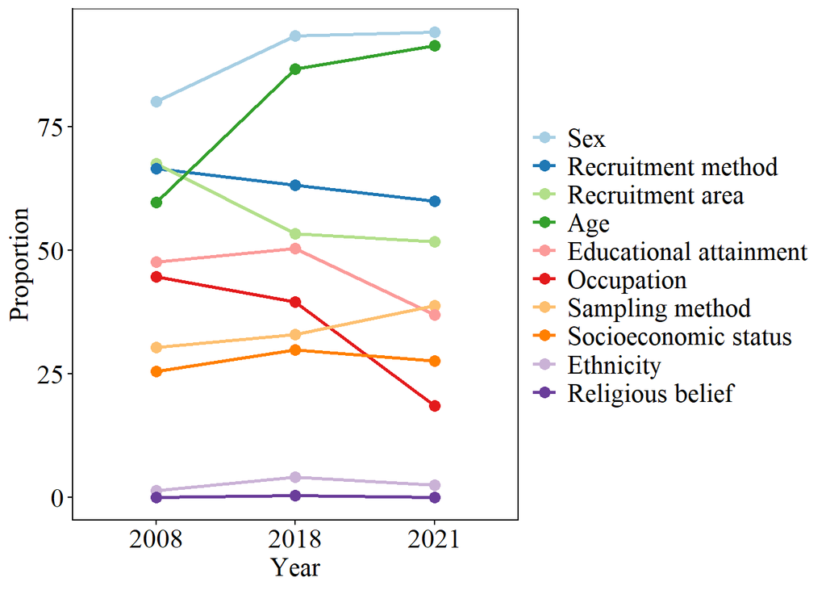

```r
Journal_report <- bind_rows(Journal_year2008_report2,Journal_year2018_report2,Journal_year2021_report2) %>%
  dplyr::filter(Var1 == "Reported") %>%
  dplyr::add_row(data.frame(Var1 = c("Reported","Reported"),
                            Freq = c(0,0),
                            col_names = c("Religious","Religious"),
                            proportion = c(0,0),
                            Year = c("2008","2021"))) %>%
  dplyr::mutate(col_names = factor(col_names,
                                   levels = c("Gender","Recruitment Method","Recruitment Area",
                                              "Age","Educational Attainment","Occupation",
                                              "Sampling Method","SES","Ethnicity",
                                              "Religious"),
                                   labels = c("Sex","Recruitment method","Recruitment area",
                                              "Age","Educational attainment","Occupation",
                                              "Sampling method","Socioeconomic status","Ethnicity",
                                              "Religious belief")))

Journal_report_year <- Journal_report %>%
  ggplot(aes(x = Year, y = proportion, color = col_names, group = col_names))+
  geom_line(size = 1)+
  geom_point(size = 3)+
  labs(y="Proportion", x = "Year")+
  theme_classic()+
  theme(panel.border =element_rect(fill=NA,color="black"),
        legend.box.spacing = unit(2,"pt"),
        legend.text = element_text(size = 16, family = "serif"),
        legend.title = element_blank(),
        axis.title = element_text(size = 16,family = "serif"),
        axis.text = element_text(size = 16,family = "serif"))+
  scale_color_brewer(palette = "Paired")


ggsave(here("3_Data_Analysis","3_2_image","Journal_report_year.pdf"),
       Journal_report_year, device = "pdf", width=12, height = 9)

ggsave(here("3_Data_Analysis","3_2_image","Journal_report_year.png"),
       Journal_report_year, device = "png", width=12, height = 9, dpi = 600)

Journal_report_year
```

## Journal reported within different target population

general

```r
Journal_general_population <- Journal %>%
  dplyr::filter(Target_Population_N != 1) %>%
  dplyr::mutate(Subjects_Recruitment_Area = ifelse(Subjects_Recruitment_Area == 0, 0, 1),
                Sampling_Method = ifelse(Sampling_Method == 0, 0 ,1),
                SES_N = ifelse(SES_N == 0, 0, 1),
                Subjects_Recruitment_Method_N = ifelse(Subjects_Recruitment_Method_N == 0, 0, 1)) %>%
  dplyr::group_by(Article_IDs,Study_Number) %>%
  dplyr::summarise(Age = max(Age) > 0,
                   Gender = max(Gender) > 0,
                   Religious = max(Religious) > 0,
                   Ethnicity = max(Ethnicity) > 0,
                   Sampling_Method = max(Sampling_Method) > 0,
                   Recruitment_Area = max(Subjects_Recruitment_Area) > 0,
                   Recruitment_Method = max(Subjects_Recruitment_Method_N) > 0,
                   SES = max(SES_N) > 0,
                   .groups = "drop") %>%
  dplyr::select(3:last_col())


report_list <- list()

for (i in names(Journal_general_population)){


  report_table <- data.frame(table(Journal_general_population[[i]])) %>%
    dplyr::mutate(col_names = names(Journal_general_population[i]),
                  proportion = Freq / sum(Freq))

  report_list[[i]] <- report_table

}

Journal_general_population_report <- do.call(rbind, report_list) %>%
  dplyr::mutate(Var1 = ifelse(Var1 == "TRUE", "Reported","Unreported"))


### Calculate reported status of Educational_Attainment and Occupation
Journal_general_education_occupation <- Journal %>%
  dplyr::filter(Target_Population_N != 1) %>%
  dplyr::filter(Sample_Type_N %in% c(4,5)) %>%
  dplyr::group_by(Article_IDs,Study_Number) %>%
  dplyr::summarise(Educational_Attainment_N = max(Educational_Attainment_N) > 0,
                   Occupation_N = max(Occupation_N) > 0,.groups = "drop")



table(Journal_general_education_occupation$Educational_Attainment_N)
```

```
##
## FALSE  TRUE
##    73    42
```

```r
table(Journal_general_education_occupation$Occupation_N)
```

```
##
## FALSE  TRUE
##   101    14
```

```r
Journal_general_education_occupation_table <- data.frame(Var1 = c("Unreported","Reported",
                                                            "Unreported","Reported"),
                                                   Freq = c(73,42,101,14),
                                                   col_names= c("Educational_Attainment",
                                                                "Educational_Attainment",
                                                                "Occupation","Occupation"),
                                                   proportion = c(73/(73+42),42/(73+42),
                                                                  101/(101+14),14/(101+14)))

Journal_general_report2 <- rbind(Journal_general_population_report,
                                  Journal_general_education_occupation_table) %>%
  dplyr::mutate(proportion = proportion *100) %>%
  dplyr::mutate(Target_population = "General population")
```

special

```r
Journal_special_population <- Journal %>%
  dplyr::filter(Target_Population_N == 1) %>%
  dplyr::mutate(Subjects_Recruitment_Area = ifelse(Subjects_Recruitment_Area == 0, 0, 1),
                Sampling_Method = ifelse(Sampling_Method == 0, 0 ,1),
                SES_N = ifelse(SES_N == 0, 0, 1),
                Subjects_Recruitment_Method_N = ifelse(Subjects_Recruitment_Method_N == 0, 0, 1)) %>%
  dplyr::group_by(Article_IDs,Study_Number) %>%
  dplyr::summarise(Age = max(Age) > 0,
                   Gender = max(Gender) > 0,
                   Religious = max(Religious) > 0,
                   Ethnicity = max(Ethnicity) > 0,
                   Sampling_Method = max(Sampling_Method) > 0,
                   Recruitment_Area = max(Subjects_Recruitment_Area) > 0,
                   Recruitment_Method = max(Subjects_Recruitment_Method_N) > 0,
                   SES = max(SES_N) > 0,
                   .groups = "drop") %>%
  dplyr::select(3:last_col())


report_list <- list()

for (i in names(Journal_special_population)){


  report_table <- data.frame(table(Journal_special_population[[i]])) %>%
    dplyr::mutate(col_names = names(Journal_special_population[i]),
                  proportion = Freq / sum(Freq))

  report_list[[i]] <- report_table

}

Journal_special_population_report <- do.call(rbind, report_list) %>%
  dplyr::mutate(Var1 = ifelse(Var1 == "TRUE", "Reported","Unreported"))


### Calculate reported status of Educational_Attainment and Occupation
Journal_special_education_occupation <- Journal %>%
  dplyr::filter(Target_Population_N == 1) %>%
  dplyr::filter(Sample_Type_N %in% c(4,5)) %>%
  dplyr::group_by(Article_IDs,Study_Number) %>%
  dplyr::summarise(Educational_Attainment_N = max(Educational_Attainment_N) > 0,
                   Occupation_N = max(Occupation_N) > 0,.groups = "drop")



table(Journal_special_education_occupation$Educational_Attainment_N)
```

```
##
## FALSE  TRUE
##    93    98
```

```r
table(Journal_special_education_occupation$Occupation_N)
```

```
##
## FALSE  TRUE
##   100    91
```

```r
Journal_special_education_occupation_table <- data.frame(Var1 = c("Unreported","Reported",
                                                            "Unreported","Reported"),
                                                   Freq = c(93,98,100,91),
                                                   col_names= c("Educational_Attainment",
                                                                "Educational_Attainment",
                                                                "Occupation","Occupation"),
                                                   proportion = c(93/(93+98),98/(93+98),
                                                                  100/(100+91),91/(100+91)))

Journal_special_report2 <- rbind(Journal_special_population_report,
                                  Journal_special_education_occupation_table) %>%
  dplyr::mutate(proportion = proportion *100) %>%
  dplyr::mutate(Target_population = "Special population")
```

combine two data.frame and visualize

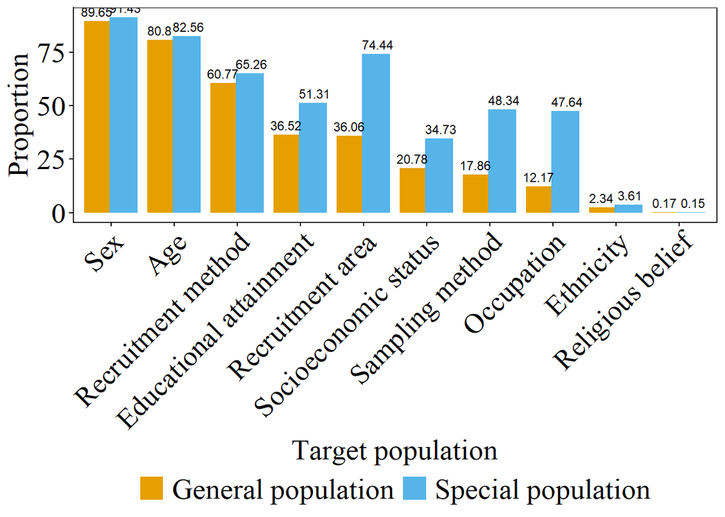

```r
Journal_target_population_report <- full_join(Journal_general_report2,
                                              Journal_special_report2,
                                              by = c("col_names", "Var1", "Freq", "proportion","Target_population")) %>%
  dplyr::filter(Var1 == "Reported")


## set factor
Journal_target_population_report_factor <- Journal_target_population_report %>%
  dplyr::filter(Target_population == "General population") %>%
  dplyr::arrange(desc(proportion)) %>%
  dplyr::pull(col_names)


Journal_target_population_report2 <- Journal_target_population_report %>%
dplyr::mutate(col_names = factor(col_names,
                                 levels = Journal_target_population_report_factor,
                                 labels = c(labels = c("Sex", "Age","Recruitment method","Educational attainment",
                                                       "Recruitment area","Socioeconomic status","Sampling method",
                                               "Occupation", "Ethnicity", "Religious belief"))))


## plot
Journal_report_target_population <- Journal_target_population_report2 %>%
  ggplot(aes(x = col_names, y = proportion, fill = Target_population, group = Target_population))+
  geom_bar(stat = "identity", position = position_dodge(width = 0.8))+
  geom_text(aes(label = round(proportion,2)),
            position = position_dodge(width = 0.9),
            vjust = -0.5,
            size =3)+
  labs(y="Proportion", x = "Target population")+
  theme_classic()+
  theme(panel.border =element_rect(fill=NA,color="black"),
        legend.position = "bottom",
        legend.box.spacing = unit(2,"pt"),
        legend.text = element_text(size = 20, family = "serif"),
        legend.title = element_blank(),
        axis.title = element_text(size = 20,family = "serif"),
        axis.text = element_text(size = 20,family = "serif"))+
  scale_x_discrete(guide = guide_axis(angle = 45))+
  scale_fill_okabe_ito()

ggsave(here("3_Data_Analysis","3_2_image","Journal_report_target_population.pdf"), Journal_report_target_population, device = "pdf", width=12, height = 9)

ggsave(here("3_Data_Analysis","3_2_image","Journal_report_target_population.png"), Journal_report_target_population, device = "png", width=12, height = 9, dpi = 600)

Journal_report_target_population
```

## the exporation analyse in special population

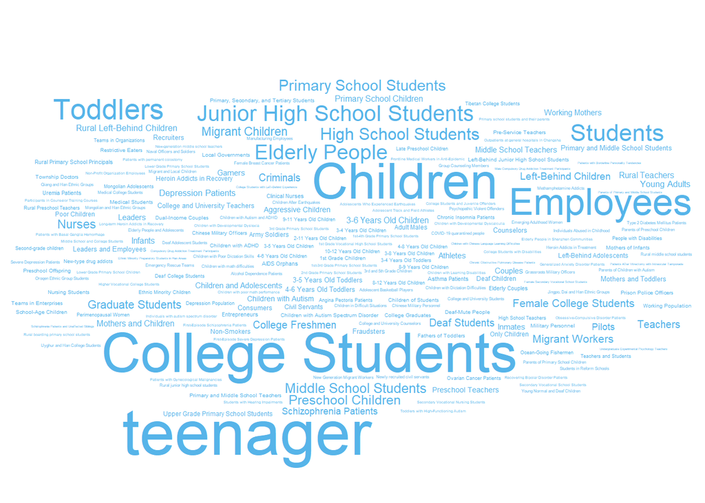

```r
# Journal_special_visual <- Journal_special_target_population2 %>%
#   dplyr::group_by(Recode_target_population) %>%
#   dplyr::summarise(n = n())


## save and translate Chinese into English

# writexl::write_xlsx(Journal_special_visual,"Journal_special_visual.xlsx")
Journal_special_visual2 <- Journal_special_population_translation %>%
  dplyr::group_by(Target_Population_English) %>%
  dplyr::summarise(Count = sum(Count)) %>%
  dplyr::ungroup() %>%
  dplyr::mutate(cate = ifelse(Count == 1,"one",Count))

Suppl_Fig_Special_Wordcloud <- Journal_special_visual2 %>%
  ggplot(aes(label = Target_Population_English,
             size = Count)) +
  geom_text_wordcloud(area_corr = TRUE,
                      color = "#56B4E9") +
  scale_size_area(max_size = 50) +
  theme_minimal()

# display.brewer.all(colorblindFriendly = TRUE)

Suppl_Fig_Special_Wordcloud
```

bar plot

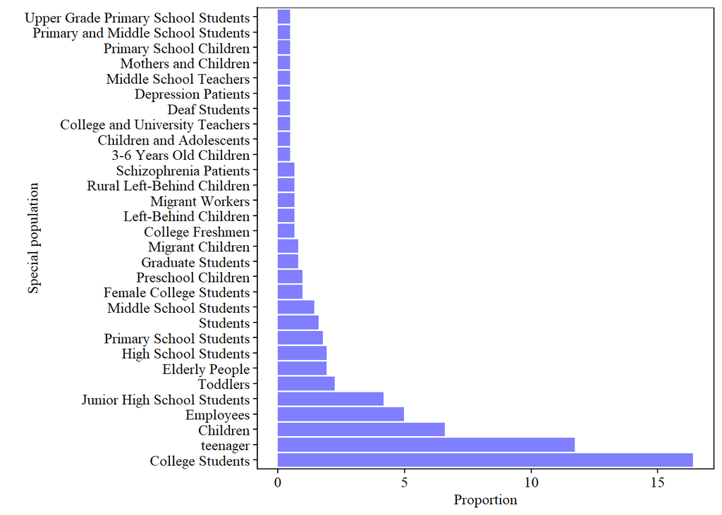

```r
Journal_special_visual_gt2 <- Journal_special_visual2 %>%
  dplyr::filter(Count > 2) %>%
  dplyr::mutate(Prop = (Count/622)*100) %>%
  dplyr::arrange(desc(Prop))


## factor
Journal_special_visual_gt2_factor <- Journal_special_visual_gt2 %>%
  dplyr::pull(Target_Population_English)

Journal_special_visual_gt3 <- Journal_special_visual_gt2 %>%
  dplyr::mutate(Target_Population_English = factor(Target_Population_English,
                                                   levels = Journal_special_visual_gt2_factor))


Suppl_Fig_Journal_special_visual_bar <-  Journal_special_visual_gt3 %>%
ggplot(aes(x = Target_Population_English,y = Prop))+
  geom_col(fill = "blue",alpha = 0.5)+
  xlab("Special population")+
  ylab("Proportion")+
  coord_flip()+
  theme_classic()+
  theme(axis.title.y = element_text(vjust = -5),
        panel.border =element_rect(fill=NA,color="black"),
        legend.position = "bottom",
        legend.box.spacing = unit(2,"pt"),
        legend.text = element_text(size = 10, family = "serif"),
        legend.title = element_blank(),
        axis.title = element_text(size = 10,family = "serif"),
        axis.text = element_text(size = 10,family = "serif"))

Suppl_Fig_Journal_special_visual_bar
```

[figure not shown]

```r
Suppl_Fig_Special_Wordcloud_Barplot <- Suppl_Fig_Special_Wordcloud + Suppl_Fig_Journal_special_visual_bar


Suppl_Fig_Special_Wordcloud_Barplot
```

```r
ggsave(here("3_Data_Analysis","3_2_image","Suppl_Fig_Special_Wordcloud_Barplot.pdf"),
       Suppl_Fig_Special_Wordcloud_Barplot, device = "pdf", width=18, height = 9)

ggsave(here("3_Data_Analysis","3_2_image","Suppl_Fig_Special_Wordcloud_Barplot.png"),
       Suppl_Fig_Special_Wordcloud_Barplot, device = "png", width=18, height = 9, dpi = 600)
```

```r
#  num of different targetpopulation

Journal_special_adolecent <- Journal_special_target_population2 %>%
  dplyr::filter(grepl("儿童|青少年|幼儿",Recode_target_population))


Journal_sepcial_primaryhigh <- Journal_special_target_population2 %>%
  dplyr::filter(Recode_target_population == "小学生" | Recode_target_population == "中学生" | Recode_target_population == "中小学生"| Recode_target_population == "初中生"| Recode_target_population == "高中生"| Recode_target_population == "中职生") %>%
  dplyr::distinct(Article_IDs)
```

create BF func, It is consistent with the analyzed function in the formal Rmd.

```r
BayesMultiNomial <- function(dataset, factor, observed, expected, default_prior = TRUE, prior = NA){
  # datase - the input dataframe
  # factor - column name of the factor,
  # observed - column name of the column contains counts information for the observed,
  # expected - column name of the column contains counts information for the expected,
  # default_prior - whether use the default, defused prior
  # prior - priors defined by users

  fact_level <- dataset %>% dplyr::select(all_of(factor)) %>% dplyr::pull()
  observed_data <- dataset %>% dplyr::select(all_of(observed)) %>% dplyr::pull()
  names(observed_data) <- fact_level
  expected_data <- dataset %>% dplyr::select(all_of(expected)) %>% dplyr::pull()
  n_levels <- length(observed_data)


  if (default_prior & all(is.na(prior))) {
    prior <- rep(1, n_levels)
  } else{
    if (is.character(prior)){
      prior <- dataset %>% dplyr::select(all_of(prior)) %>% dplyr::pull()
    } else if (is.array(prior)){
      prior <-  prior
    } else if (is.numeric(prior)){
      prior <-  prior
    } else{
      print("prior much a column of the input data or a vector")
    }
  }

  alphas <- prior
  counts <- observed_data
  thetas <- expected_data

  if(sum(thetas) != 1) {
    thetas <- thetas/sum(thetas)
    }

  expected <- setNames(sum(counts)*thetas, names(counts))

  lbeta.xa <- sum(lgamma(alphas + counts)) - lgamma(sum(alphas + counts))
  lbeta.a  <- sum(lgamma(alphas)) - lgamma(sum(alphas))

  if (any(rowSums(cbind(thetas, counts)) == 0)) {
    LogBFa0 <- (lbeta.xa-lbeta.a)
  } else {
     LogBFa0 <- (lbeta.xa-lbeta.a) + (0 - sum(counts * log(thetas)))
  }

  BF <- data.frame(LogBFa0 = LogBFa0,
                   BFa0    = exp(LogBFa0),
                   BF0a    = 1/exp(LogBFa0))

  return(list(BF       = BF,
              expected = expected))

}
```

**Note:** For all analyses in this document, Log(BFa0) denotes the natural logarithm (ln) of BFa0, as specified in the custom function.

## Two data sources are respectively compared with the census data and CFPS

I process the data of gender, age and edu.

## gender

process data

```r
## process census 6th
Census6_gender2 <- Census6_gender %>%
  dplyr::rename(Data_Source = 1) %>%
  dplyr::mutate(n = NA)

## combine data
SupplH2_gender_general <- H2_gender_general %>%
  dplyr::rename(Data_Source = Data_source) %>%
  rbind(H1_gender_general) %>%
  dplyr::filter(Data_Source != "Chinese participants") %>%
  rbind(Census6_gender2) %>%
  dplyr::mutate(Data_Source = factor(Data_Source,
                                     levels = c("Census6","Census7",
                                                "BTS Chinese","CFPS2018",
                                                "Journal")))
```

visulize

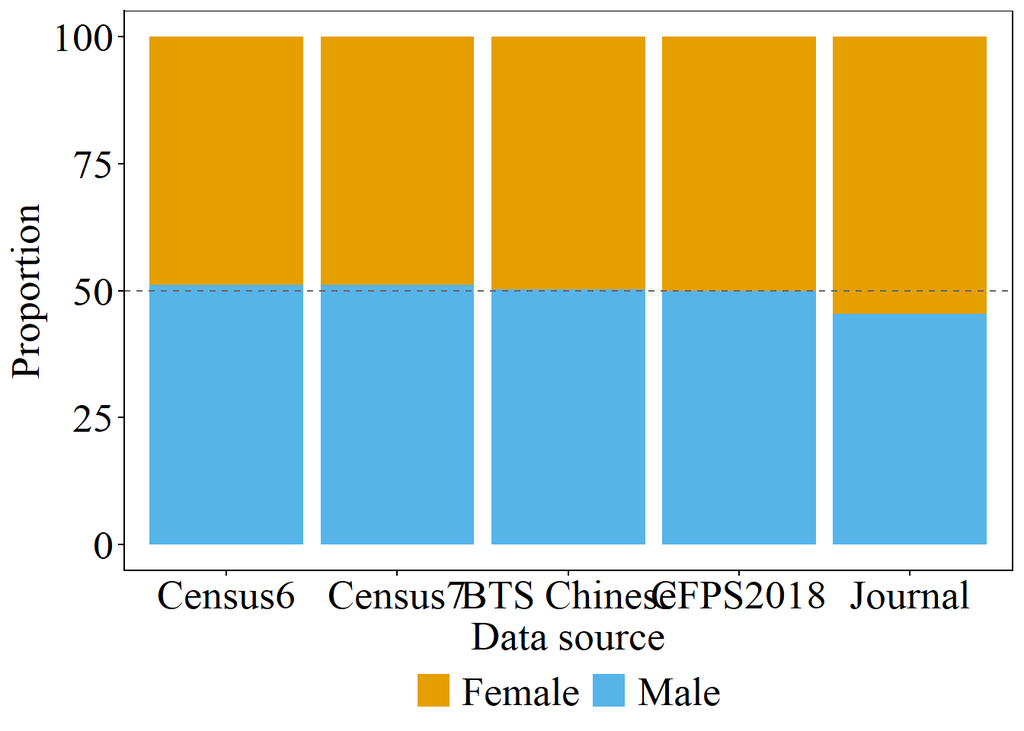

```r
Suppl_Fig_H2_gender_general <- ggplot(SupplH2_gender_general,aes(Data_Source,Proportion,fill= Gender))+
  geom_col()+
  geom_hline(yintercept = 50, linetype = "dashed", color = "#666666")+
  labs(y="Proportion",x = "Data source")+
  theme_classic()+
  theme(panel.border =element_rect(fill=NA,color="black"),
        legend.position = "bottom",
        legend.box.spacing = unit(2,"pt"),
        legend.text = element_text(size = 20, family = "serif"),
        legend.title = element_blank(),
        axis.title = element_text(size = 20,family = "serif"),
        axis.text = element_text(size = 20,family = "serif"))+
  scale_fill_okabe_ito()


ggsave(here("3_Data_Analysis","3_2_image","Suppl_Fig_H2_gender_general.pdf"),
       Suppl_Fig_H2_gender_general, device = "pdf", width=18, height = 9)

ggsave(here("3_Data_Analysis","3_2_image","Suppl_Fig_H2_gender_general.png"),
       Suppl_Fig_H2_gender_general, device = "png", width=18, height = 9, dpi = 600)

Suppl_Fig_H2_gender_general
```

BF calculate

```r
SupplH2_gender_general_bayes <- SupplH2_gender_general %>%
  dplyr::select(Gender,Data_Source,Proportion) %>%
  pivot_wider(names_from = Data_Source,values_from = Proportion)


## Journal VS Census6
SupplH2_BF_gender_Journal_Census6 <- BayesMultiNomial(dataset = SupplH2_gender_general_bayes,
                                             factor = "Gender",
                                             observed = "Journal",
                                             expected = "Census6")

## BTS VS Census6
SupplH2_BF_gender_BTS_Census6 <- BayesMultiNomial(dataset = SupplH2_gender_general_bayes,
                                             factor = "Gender",
                                             observed = "BTS Chinese",
                                             expected = "Census6")

## Journal VS Census7
SupplH2_BF_gender_Journal_Census7 <- BayesMultiNomial(dataset = SupplH2_gender_general_bayes,
                                             factor = "Gender",
                                             observed = "Journal",
                                             expected = "Census7")

## BTS VS Census7
SupplH2_BF_gender_BTS_Census7 <- BayesMultiNomial(dataset = SupplH2_gender_general_bayes,
                                             factor = "Gender",
                                             observed = "BTS Chinese",
                                             expected = "Census7")

## Journal VS CFPS2018
SupplH2_BF_gender_Journal_CFPS <- BayesMultiNomial(dataset = SupplH2_gender_general_bayes,
                                             factor = "Gender",
                                             observed = "Journal",
                                             expected = "CFPS2018")

## BTS VS CFPS2018
SupplH2_BF_gender_BTS_CFPS <- BayesMultiNomial(dataset = SupplH2_gender_general_bayes,
                                             factor = "Gender",
                                             observed = "BTS Chinese",
                                             expected = "CFPS2018")
```

Journal vs Census6: $Log(BF_{a0})$ = -1.4396936.

BTS vs Census6: $Log(BF_{a0})$ = -2.0646277.

Journal vs Census7: $Log(BF_{a0})$ = -1.4442418.

BTS vs Census7: $Log(BF_{a0})$ = -2.0654125.

Journal vs CFPS2018: $Log(BF_{a0})$ = -1.6831789.

BTS vs CFPS2018: $Log(BF_{a0})$ = -2.0834187.

## age

process data

```r
## BTS
H1_age_general_BTS <- H1_age_general %>%
  dplyr::filter(Data_Source == "BTS Chinese")

## Journal
H1_age_general_Journal <- H1_age_general %>%
  dplyr::filter(Data_Source == "Journal")

# ## combine census6 and census7
# Census_age_five <- rbind(Census6_age_five5,Census7_age_five5)
```

visualize Census7, BTS Chinese and Journal

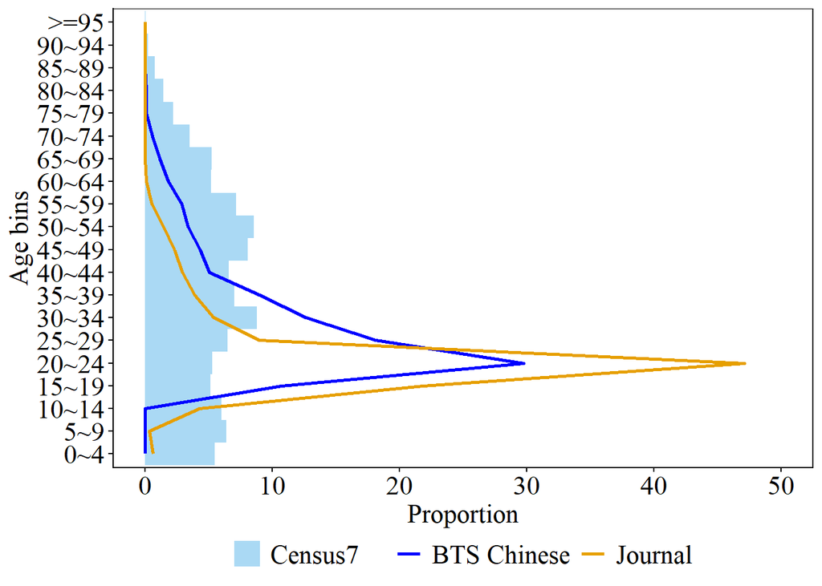

```r
SupplH2_Census7_age_general <- ggplot(data= Census7_age_five5,
                              aes(x=ageBins,
                                  y= Proportion, fill=Data_Source)) +
  geom_col(alpha=0.5, width = 1) +
  geom_line(data = H1_age_general_BTS,
            aes(x = ageBins, y = Proportion, group = 1, color = "BTS Chinese" ),
            size = 1) +
  geom_line(data = H1_age_general_Journal,
            aes(x = ageBins, y = Proportion, group = 1,color = "Journal"),
            size = 1) +
  scale_y_continuous(limits = c(0,50))+
  coord_flip() +
  labs(y="Proportion", x = "Age bins")+
  theme_classic()+
  theme(panel.border =element_rect(fill=NA,color="black"),
        legend.position = "bottom",
        legend.box.spacing = unit(2,"pt"),
        legend.text = element_text(size = 16, family = "serif"),
        legend.title = element_blank(),
        axis.title = element_text(size = 16,family = "serif"),
        axis.text = element_text(size = 16,family = "serif"))+
  scale_fill_manual(values = c("Census7" = "#56B4E9")) +
  scale_color_manual(values = c("BTS Chinese"= "blue", "Journal" = "#E69F00"))


ggsave(here("3_Data_Analysis","3_2_image","SupplH2_Census7_age_general.pdf"),
       SupplH2_Census7_age_general, device = "pdf", width=18, height = 9)

ggsave(here("3_Data_Analysis","3_2_image","SupplH2_Census7_age_general.png"),
       SupplH2_Census7_age_general, device = "png", width=18, height = 9, dpi = 600)

SupplH2_Census7_age_general
```

visualize Census6, BTS Chinese and Journal

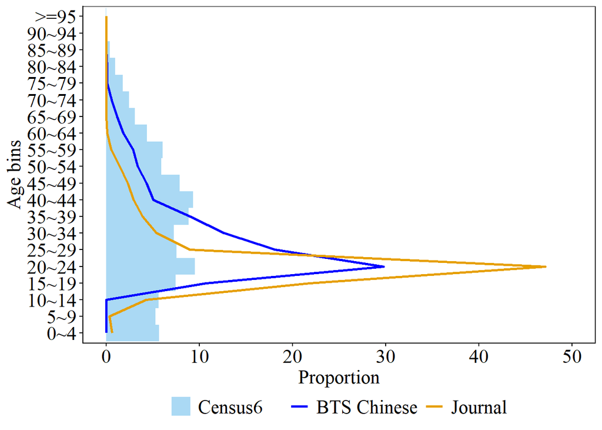

```r
SupplH2_Census6_age_general <- ggplot(data= Census6_age_five5,
                              aes(x=ageBins,
                                  y= Proportion, fill=Data_Source)) +
  geom_col(alpha=0.5, width = 1) +
  geom_line(data = H1_age_general_BTS,
            aes(x = ageBins, y = Proportion, group = 1, color = "BTS Chinese"),
            size = 1) +
  geom_line(data = H1_age_general_Journal,
            aes(x = ageBins, y = Proportion, group = 1, color = "Journal"),
            size = 1) +
  scale_y_continuous(limits = c(0,50))+
  coord_flip() +
  labs(y="Proportion", x = "Age bins")+
  theme_classic()+
  theme(panel.border =element_rect(fill=NA,color="black"),
        legend.position = "bottom",
        legend.box.spacing = unit(2,"pt"),
        legend.text = element_text(size = 16, family = "serif"),
        legend.title = element_blank(),
        axis.title = element_text(size = 16,family = "serif"),
        axis.text = element_text(size = 16,family = "serif"))+
  scale_fill_manual(values = c("Census6" = "#56B4E9")) +
  scale_color_manual(values = c("BTS Chinese"= "blue", "Journal" = "#E69F00"))

ggsave(here("3_Data_Analysis","3_2_image","SupplH2_Census6_age_general.pdf"),
       SupplH2_Census6_age_general, device = "pdf", width=18, height = 9)

ggsave(here("3_Data_Analysis","3_2_image","SupplH2_Census6_age_general.png"),
       SupplH2_Census6_age_general, device = "png", width=18, height = 9, dpi = 600)

SupplH2_Census6_age_general
```

BF data

```r
## Census6 PsyStages
Suppl_Census6_age_PsyStages <- Census6_age_PsyStages %>%
  dplyr::select(ageBins,Proportion) %>%
  dplyr::rename(Census6 = 2)

## Census7 PsyStages
Suppl_Census7_age_PsyStages <- Census7_age_PsyStages %>%
  dplyr::select(ageBins,Proportion) %>%
  dplyr::rename(Census7 = 2)


## Census6 interval10
Suppl_Census6_age_interval10 <- Census6_age_interval10 %>%
  dplyr::select(ageBins,Proportion) %>%
  dplyr::rename(Census6 = 2)

## Census7 interval10
Suppl_Census7_age_interval10 <- Census7_age_interval10 %>%
  dplyr::select(ageBins,Proportion) %>%
  dplyr::rename(Census7 = 2)


## combine data
## PsyStages
Suppl_PsyStages_bayes <- left_join(H1_PsyStages_bayes_general,
                                Suppl_Census7_age_PsyStages,
                                by = "ageBins") %>%
  left_join(Suppl_Census6_age_PsyStages,
            by = "ageBins")


## interval10
Suppl_interval10_bayes <- left_join(H1_interval10_bayes_general,
                                 Suppl_Census7_age_interval10,
                             by = "ageBins") %>%
  left_join(Suppl_Census6_age_interval10,
            by = "ageBins")
```

Census6, BTS Chinese, and Journal

```r
## BTS PsyStages VS Census6
SupplH2_BF_Psystages_BTS_Census6 <- BayesMultiNomial(dataset = Suppl_PsyStages_bayes,
                                             factor = "ageBins",
                                             observed = "BTS Chinese",
                                             expected = "Census6")


## BTS interval10 VS Census6
SupplH2_BF_interval10_BTS_Census6 <- BayesMultiNomial(dataset = Suppl_interval10_bayes,
                                             factor = "ageBins",
                                             observed = "BTS Chinese",
                                             expected = "Census6")


## Journal PsyStages VS Census6
SupplH2_BF_Psystages_Journal_Census6 <- BayesMultiNomial(dataset = Suppl_PsyStages_bayes,
                                             factor = "ageBins",
                                             observed = "Journal",
                                             expected = "Census6")

## Journal interval10 VS Census6
SupplH2_BF_interval10_Journal_Census6 <- BayesMultiNomial(dataset =Suppl_interval10_bayes,
                                             factor = "ageBins",
                                             observed = "Journal",
                                             expected = "Census6")
```

BTS vs Census6 in PsyStages: $Log(BF_{a0})$ = 43.8185603.

BTS vs Census6 in interval10: $Log(BF_{a0})$ = 25.5016254.

Journal vs Census6 in Psystages: $Log(BF_{a0})$ = 65.7296588.

Journal vs Census6 in interval10: $Log(BF_{a0})$ = 52.9165246.

Census7, BTS Chinese, and Journal

```r
## BTS PsyStages VS Census7
SupplH2_BF_Psystages_BTS_Census7 <- BayesMultiNomial(dataset = Suppl_PsyStages_bayes,
                                             factor = "ageBins",
                                             observed = "BTS Chinese",
                                             expected = "Census7")


## BTS interval10 VS Census7
SupplH2_BF_interval10_BTS_Census7 <- BayesMultiNomial(dataset = Suppl_interval10_bayes,
                                             factor = "ageBins",
                                             observed = "BTS Chinese",
                                             expected = "Census7")


## Journal PsyStages VS Census7
SupplH2_BF_Psystages_Journal_Census7 <- BayesMultiNomial(dataset = Suppl_PsyStages_bayes,
                                             factor = "ageBins",
                                             observed = "Journal",
                                             expected = "Census7")

## Journal interval10 VS Census7
SupplH2_BF_interval10_Journal_Census7 <- BayesMultiNomial(dataset =Suppl_interval10_bayes,
                                             factor = "ageBins",
                                             observed = "Journal",
                                             expected = "Census7")
```

BTS vs Census7 in PsyStages: $Log(BF_{a0})$ = 67.6243434.

BTS vs Census7 in interval10: $Log(BF_{a0})$ = 41.64643.

Journal vs Census7 in Psystages: $Log(BF_{a0})$ = 99.4160111.

Journal vs Census7 in interval10: $Log(BF_{a0})$ = 75.0269674.

## edu

process Census6 data

```r
Suppl_Census6_edu_adults <- Census6_edu %>%
  dplyr::select(1,2,5,8,11,14,17,20,23) %>%
  dplyr::rename(Age = 1,n = 2,
                Never_attended_school = 3,  Primary_school = 4,
                Junior_high_school = 5, Senior_high_school = 6,
                Junior_college = 7,Undergraduate_education = 8,
                Graduate_education = 9) %>%
  dplyr::slice(21:22, seq(23,101,by = 6)) %>%
  dplyr::mutate(across(-1,as.numeric))


## college
Suppl_Census6_college <- Suppl_Census6_edu_adults %>%
  dplyr::summarise(`Less-than-college` = sum(across(3:6)),
                   `College-or-above` = sum(across(7:9))) %>%
  tidyr::pivot_longer(cols = c(1,2),
                      names_to = "Educational_attainment",
                      values_to = "Num") %>%
  dplyr::mutate(Proportion = Num/sum(Num)*100) %>%
  dplyr::select(-Num) %>%
  dplyr::rename(Census6 = 2)

## high school
Suppl_Census6_high_school <- Suppl_Census6_edu_adults %>%
  dplyr::summarise(`Less-than-high-school` = sum(across(3:5)),
                   `High-school-or-above` = sum(across(6:9))) %>%
  tidyr::pivot_longer(cols = c(1,2),
                      names_to = "Educational_attainment",
                      values_to = "Num") %>%
  dplyr::mutate(Proportion = Num/sum(Num)*100) %>%
  dplyr::select(-Num)%>%
  dplyr::rename(Census6 = 2)
```

process Census7 data

```r
## Census
Suppl_Census7_college <- Census7_college %>%
  dplyr::select(Educational_attainment,Proportion) %>%
  dplyr::rename(Census7 = 2)

Suppl_Census7_high_school <- Census7_high_school %>%
  dplyr::select(Educational_attainment,Proportion) %>%
  dplyr::rename(Census7 = 2)
```

process CFPS2018 data

```r
Suppl_CFPS2018_edu_college <- CFPS2018_edu_college %>%
  dplyr::select(Educational_attainment,Proportion) %>%
  dplyr::rename(CFPS2018 = 2)


Suppl_CFPS2018_edu_high_school <- CFPS2018_edu_high_school %>%
  dplyr::select(Educational_attainment,Proportion) %>%
  dplyr::rename(CFPS2018 = 2)
```

combine all edu data

```r
## college
Suppl_college <- left_join(H1_edu_college_bayes,
                           Suppl_Census7_college,
                           by = "Educational_attainment") %>%
  left_join(Suppl_CFPS2018_edu_college,
            by = "Educational_attainment") %>%
  left_join(Suppl_Census6_college,
             by = "Educational_attainment")


## high school
Suppl_highschool <- left_join(H1_edu_highschool_bayes,
                              Suppl_Census7_high_school,
                              by = "Educational_attainment") %>%
  left_join(Suppl_CFPS2018_edu_high_school,by = "Educational_attainment") %>%
  left_join(Suppl_Census6_high_school,
             by = "Educational_attainment")
```

BF Journal, BTS and Census6

```r
## College
Suppl_BF_college_BTS_Census6 <-  BayesMultiNomial(dataset = Suppl_college,
                                             factor = "Educational_attainment",
                                             observed = "BTS Chinese",
                                             expected = "Census6")

Suppl_BF_college_Journal_Census6 <-  BayesMultiNomial(dataset = Suppl_college,
                                             factor = "Educational_attainment",
                                             observed = "Journal",
                                             expected = "Census6")


## high school
Suppl_BF_highschool_BTS_Census6 <-  BayesMultiNomial(dataset = Suppl_highschool,
                                             factor = "Educational_attainment",
                                             observed = "BTS Chinese",
                                             expected = "Census6")

Suppl_BF_highschool_Journal_Census6 <-  BayesMultiNomial(dataset = Suppl_highschool,
                                             factor = "Educational_attainment",
                                             observed = "Journal",
                                             expected = "Census6")
```

BTS vs Census6 in college: $Log(BF_{a0})$ = 148.2187279.

Journal vs Census6 in college: $Log(BF_{a0})$ = 160.6080304.

BTS vs Census6 in high school: $Log(BF_{a0})$ = 113.6453389.

Journal vs Census6 in high school: $Log(BF_{a0})$ = 95.7564028.

BF Journal, BTS and Census7

```r
## College
Suppl_BF_college_BTS_Census7 <-  BayesMultiNomial(dataset = Suppl_college,
                                             factor = "Educational_attainment",
                                             observed = "BTS Chinese",
                                             expected = "Census7")

Suppl_BF_college_Journal_Census7 <-  BayesMultiNomial(dataset = Suppl_college,
                                             factor = "Educational_attainment",
                                             observed = "Journal",
                                             expected = "Census7")


## high school
Suppl_BF_highschool_BTS_Census7 <-  BayesMultiNomial(dataset = Suppl_highschool,
                                             factor = "Educational_attainment",
                                             observed = "BTS Chinese",
                                             expected = "Census7")

Suppl_BF_highschool_Journal_Census7 <-  BayesMultiNomial(dataset = Suppl_highschool,
                                             factor = "Educational_attainment",
                                             observed = "Journal",
                                             expected = "Census7")
```

BTS vs Census7 in college: $Log(BF_{a0})$ = 101.9486814.

Journal vs Census7 in college: $Log(BF_{a0})$ = 112.3329097.

BTS vs Census7 in high school: $Log(BF_{a0})$ = 84.814019.

Journal vs Census7 in high school: $Log(BF_{a0})$ = 68.9483252.

## Abstract report

Abstract1 subjects information reported of Chinese journal general population

```r
Journal_abstract_report_general <- Journal %>%
  dplyr::select(Article_IDs_N,Study_Number,Subjects_Group,
                Target_Population_N,Sample_Type_N,Abstract1,Abstract2) %>%
  dplyr::filter(Sample_Type_N != 5) %>%
  dplyr::filter(Target_Population_N != 1) %>%
  dplyr::group_by(Article_IDs_N) %>%
  dplyr::mutate(Study_Type = ifelse(all(Sample_Type_N == 1),"Only college students",ifelse(any(grepl("1",Sample_Type_N)) & any(Sample_Type_N !=1),"College students & other populations","Only sample outside colleges"))) %>%
  dplyr::ungroup() %>%
  dplyr::arrange(desc(Abstract2)) %>%
  dplyr::group_by(Article_IDs_N) %>%
  dplyr::slice(1) %>%
  dplyr::ungroup() %>%
  dplyr::mutate(Abstract2 = ifelse(Study_Type == "Only sample outside colleges",NA,Abstract2),
                Sample_Mentioned = ifelse(Abstract1 == "0" ,"Samples not mentioned", "Samples mentioned"))

table(Journal_abstract_report_general$Abstract2)
```

```
##
##   0   1
## 225  80
```

```r
Journal_abstract_report_general_tab <- Journal_abstract_report_general %>%
  dplyr::group_by(Study_Type,Sample_Mentioned) %>%
  dplyr::summarise(n = n()) %>%
  dplyr::ungroup()
```

```
## `summarise()` has regrouped the output.
## ℹ Summaries were computed grouped by Study_Type and Sample_Mentioned.
## ℹ Output is grouped by Study_Type.
## ℹ Use `summarise(.groups = "drop_last")` to silence this message.
## ℹ Use `summarise(.by = c(Study_Type, Sample_Mentioned))` for per-operation
##   grouping (`?dplyr::dplyr_by`) instead.
```

```r
Journal_abstract_report_general_tab
```

```
## # A tibble: 6 × 3
##   Study_Type                           Sample_Mentioned          n
##   <chr>                                <chr>                 <int>
## 1 College students & other populations Samples mentioned        10
## 2 College students & other populations Samples not mentioned     7
## 3 Only college students                Samples mentioned        91
## 4 Only college students                Samples not mentioned   197
## 5 Only sample outside colleges         Samples mentioned        33
## 6 Only sample outside colleges         Samples not mentioned    11
```

```r
## save csv to calculate BF in JASP
write.csv(Journal_abstract_report_general,"Journal_abstract_report_general.csv",row.names = FALSE)
```

## Reason for current data pattern

```r
Journal_subjects_recruitment <- Journal %>%
  dplyr::select(Article_IDs,Article_Title,Study_Number_N,Subjects_Group_N,
                Target_Population_N,Sample_Type_N,Sampling_Method,Subjects_Recruitment_Method_N,
                Subjects_Recruitment_Method_info_N)

table(Journal_subjects_recruitment$Sampling_Method)
```

```
##
##    0    1    2
## 1104  223  301
```

```r
table(Journal_subjects_recruitment$Subjects_Recruitment_Method_N)
```

```
##
##   0   1 1;2   2
## 595 950   7  77
```

```r
## each articles
Journal_subjects_recruitment_articles <- Journal_subjects_recruitment %>%
  dplyr::group_by(Article_IDs) %>%
  mutate(Subjects_Recruitment_Method_cate = ifelse(all(Subjects_Recruitment_Method_N == "0"),"unreported",
                                                       ifelse(any(grepl("1", Subjects_Recruitment_Method_N)),"have offline","other"))) %>%
  dplyr::ungroup() %>%
  dplyr::group_by(Article_IDs) %>%
  dplyr::slice(1) %>%
  dplyr::ungroup()

table(Journal_subjects_recruitment_articles$Subjects_Recruitment_Method_cate)
```

```
##
## have offline        other   unreported
##          606           45          349
```

```r
(950+7)/(950+7+77)
```

```
## [1] 0.9255319
```

```r
606/(606+45)
```

```
## [1] 0.9308756
```

```r
Journal_subjects_recruitment2 <- Journal_subjects_recruitment %>%
  dplyr::filter(Target_Population_N != 1)

table(Journal_subjects_recruitment2$Subjects_Recruitment_Method_N)
```

```
##
##   0   1 1;2   2
## 278 381   3  43
```

## sample size in different study type

the sample size of different study type

```r
Journal_general_experi <- Journal %>%
  dplyr::select(Article_IDs_N,Study_Number_N,Study_Type,Sample_Size,Target_Population_N) %>%
  dplyr::mutate(Sample_Size = ifelse(Article_IDs_N == "20185082", 33, Sample_Size)) %>%
  dplyr::filter(Target_Population_N != 1) %>%
  dplyr::filter(Study_Type == 1) %>%
  dplyr::mutate(Sample_Size = as.numeric(Sample_Size)) %>%
  dplyr::filter(!is.na(Sample_Size))


Journal_general_experi_papernum <- Journal_general_experi %>%
  dplyr::distinct(Article_IDs_N)
Journal_general_experi_studynum <-  Journal_general_experi %>%
  dplyr::distinct(Article_IDs_N,Study_Number_N)
sum(Journal_general_experi$Sample_Size,rm.na = TRUE)  ## 46183
```

```
## [1] 46130
```

```r
## questionnaire
Journal_general_questionaire <- Journal %>%
  dplyr::select(Article_IDs_N,Study_Number_N,Study_Type,Sample_Size,Target_Population_N) %>%
  dplyr::filter(Target_Population_N != 1) %>%
  dplyr::filter(Study_Type == 2) %>%
  dplyr::mutate(Sample_Size = as.numeric(Sample_Size)) %>%
  dplyr::filter(!is.na(Sample_Size))


Journal_general_questionaire_papernum <- Journal_general_questionaire %>%
  dplyr::distinct(Article_IDs_N)
Journal_general_questionaire_studynum <- Journal_general_questionaire %>%
  dplyr::distinct(Article_IDs_N,Study_Number_N)
sum(Journal_general_questionaire$Sample_Size)
```

```
## [1] 68121
```

exploration analysis region data of Journal based on study type

```r
## single region
Journal_region_single_studytype <- Journal %>%
  dplyr::select(Article_IDs,Study_Number,Subjects_Group,Study_Type) %>%
  dplyr::inner_join(Journal_region_single,
                    by = c("Article_IDs","Study_Number","Subjects_Group"))

Journal_region_single_studytype2 <- Journal_region_single_studytype %>%
  dplyr::filter(Target_Population_N != 1)


## multiple region
Journal_region_multiple_IDs <- Journal_region_multiple %>%
  dplyr::pull(Article_IDs)

Journal_studytype <- Journal %>%
  dplyr::filter(Article_IDs %in% Journal_region_multiple_IDs) %>%
  dplyr::select(Article_IDs,Study_Number,Subjects_Group,Study_Type)
  # dplyr::slice(-c(4,11)) %>%


Journal_region_multiple_studytype <- Journal_region_multiple %>%
  dplyr::inner_join(Journal_studytype, by = c("Article_IDs","Study_Number","Subjects_Group")) %>%
  dplyr::filter(Target_Population_N != 1) ## only one row data

Journal_region_multiple_studytype2 <- Journal_region_multiple_studytype %>%
  tidyr::separate_rows(True_Value,sep = ";") %>%
  tidyr::separate(True_Value,c("Subjects_Recruitment_Area","Sample_Size"),sep = ":") %>%
  dplyr::mutate(Sample_Size = as.numeric(trimws(Sample_Size)),
                Sample_Size = ceiling(2500 * Sample_Size)) %>% ## sample size is 2500
  dplyr::select(Article_IDs,Study_Number,Subjects_Group,
                Study_Type,Target_Population_N,Sample_Type_N,
                Sample_Size,Subjects_Recruitment_Area)


## combine single region data and multiple region data
Journal_region <- bind_rows(Journal_region_single_studytype2,Journal_region_multiple_studytype2)


## group by study type
Journal_region_experi <- Journal_region %>%
  dplyr::filter(Study_Type == 1) %>%
  dplyr::group_by(Subjects_Recruitment_Area) %>%
  dplyr::summarise(Sample_Size = sum(Sample_Size)) %>%
  dplyr::ungroup() %>%
  dplyr::filter(Subjects_Recruitment_Area %in% China_province) %>%
  dplyr::mutate(Proportion = Sample_Size/sum(Sample_Size)*100,
                Count_Bins = cut(Proportion,
                                 breaks = c(-Inf,1,5,10,Inf),
                labels = c("<1","1~5","5~10",">=10")),
                Data_Source = "Journal_experi") %>%
  dplyr::rename(Region = Subjects_Recruitment_Area)


Journal_region_questionaire <- Journal_region %>%
  dplyr::filter(Study_Type == 2) %>%
  dplyr::group_by(Subjects_Recruitment_Area) %>%
  dplyr::summarise(Sample_Size = sum(Sample_Size)) %>%
  dplyr::ungroup() %>%
  dplyr::filter(Subjects_Recruitment_Area %in% China_province) %>%
  dplyr::mutate(Proportion = Sample_Size/sum(Sample_Size)*100,
                Count_Bins = cut(Proportion,
                                 breaks = c(-Inf,1,5,10,Inf),
                labels = c("<1","1~5","5~10",">=10")),
                Data_Source = "Journal_questionaire") %>%
  dplyr::rename(Region = Subjects_Recruitment_Area)
```

convert Journal data into four regions and seven regions

```r
## four regions & experi
Journal_region_four_experi <- merge(Journal_region_experi,China_region_four,
                              by = "Region") %>%
  dplyr::select(Region, Sample_Size, Data_Source, Region_four) %>%
  dplyr::group_by(Region_four) %>%
  dplyr::summarise(n = sum(Sample_Size)) %>%
  dplyr::ungroup() %>%
  dplyr::mutate(experi_Prop = n / sum(n) * 100)

sum(Journal_region_four_experi$experi_Prop)
```

```
## [1] 100
```

```r
## seven regions & experi
Journal_region_seven_experi <- merge(Journal_region_experi,China_region_seven,
                              by = "Region") %>%
  dplyr::select(Region, Sample_Size, Data_Source, Region_seven) %>%
  dplyr::group_by(Region_seven) %>%
  dplyr::summarise(n = sum(Sample_Size)) %>%
  dplyr::ungroup() %>%
  dplyr::mutate(experi_Prop = n / sum(n) * 100)

sum(Journal_region_seven_experi$experi_Prop)
```

```
## [1] 100
```

```r
## four regions & questionaire
Journal_region_four_questionaire <- merge(Journal_region_questionaire, China_region_four,
                              by = "Region") %>%
  dplyr::select(Region, Sample_Size, Data_Source, Region_four) %>%
  dplyr::group_by(Region_four) %>%
  dplyr::summarise(n = sum(Sample_Size)) %>%
  dplyr::ungroup() %>%
  dplyr::mutate(questionaire_Prop = n / sum(n) * 100)

sum(Journal_region_four_questionaire$questionaire_Prop)
```

```
## [1] 100
```

```r
##seven regions & questionaire
Journal_region_seven_questionaire <- merge(Journal_region_questionaire, China_region_seven,
                              by = "Region") %>%
  dplyr::select(Region, Sample_Size, Data_Source, Region_seven) %>%
  dplyr::group_by(Region_seven) %>%
  dplyr::summarise(n = sum(Sample_Size)) %>%
  dplyr::ungroup() %>%
  dplyr::mutate(questionaire_Prop = n / sum(n) * 100)

sum(Journal_region_seven_questionaire$questionaire_Prop)
```

```
## [1] 100
```

add census6’ regional data

```r
Census6_region <- Census6_region %>%
  dplyr::select(1,5) %>%
  dplyr::slice(-c(1:7)) %>%
  dplyr::rename(Region = 1, n = 2) %>%
  dplyr::mutate(n = as.numeric(n,
                               Region = gsub(" ","",Region)))

Census6_3 <- data.frame(Region = c("台湾","香港","澳门"),n =c(170283,234829,21201))


Census6_region <- rbind(Census6_region,Census6_3) %>%
  dplyr::mutate(Proportion = n / sum(n)*100) %>%
  dplyr::mutate(Count_Bins = cut(Proportion,
                                      breaks = c(-Inf,1,5,10,Inf),
                                      labels = c("<1","1~5","5~10",">=10")),
                Data_Source = "Census6")

sum(Census6_region$n) #1,333,237,182
```

```
## [1] 1333237182
```

```r
sum(Census6_region$Proportion) ## 100
```

```
## [1] 100
```

```r
## four regions
Census6_region_four <- merge(Census6_region,China_region_four,by = "Region") %>%
  dplyr::select(1,2,6) %>%
  dplyr::group_by(Region_four) %>%
  dplyr::summarise(Census6_n=sum(n)) %>%
  dplyr::mutate(Census6_Prop = Census6_n/sum(Census6_n)*100) %>%
  dplyr::select(1,3)

sum(Census6_region_four$Census6_Prop)
```

```
## [1] 100
```

```r
## seven regions
Census6_region_seven <- merge(Census6_region,China_region_seven,by= "Region") %>%
  dplyr::select(1,2,6) %>%
  dplyr::group_by(Region_seven) %>%
  dplyr::summarise(Census6_n=sum(n)) %>%
  dplyr::mutate(Census6_Prop = Census6_n/sum(Census6_n)*100) %>%
  dplyr::select(1,3)

sum(Census6_region_seven$Census6_Prop)
```

```
## [1] 100
```

To use func in main protocal

```r
BayesMultiNomial <- function(dataset, factor, observed, expected, default_prior = TRUE, prior = NA){
  # datase - the input dataframe
  # factor - column name of the factor,
  # observed - column name of the column contains counts information for the observed,
  # expected - column name of the column contains counts information for the expected,
  # default_prior - whether use the default, defused prior
  # prior - priors defined by users

  fact_level <- dataset %>% dplyr::select(all_of(factor)) %>% dplyr::pull()
  observed_data <- dataset %>% dplyr::select(all_of(observed)) %>% dplyr::pull()
  names(observed_data) <- fact_level
  expected_data <- dataset %>% dplyr::select(all_of(expected)) %>% dplyr::pull()
  n_levels <- length(observed_data)


  if (default_prior & all(is.na(prior))) {
    prior <- rep(1, n_levels)
  } else{
    if (is.character(prior)){
      prior <- dataset %>% dplyr::select(all_of(prior)) %>% dplyr::pull()
    } else if (is.array(prior)){
      prior <-  prior
    } else if (is.numeric(prior)){
      prior <-  prior
    } else{
      print("prior much a column of the input data or a vector")
    }
  }

  alphas <- prior
  counts <- observed_data
  thetas <- expected_data

  if(sum(thetas) != 1) {
    thetas <- thetas/sum(thetas)
    }

  expected <- setNames(sum(counts)*thetas, names(counts))

  lbeta.xa <- sum(lgamma(alphas + counts)) - lgamma(sum(alphas + counts))
  lbeta.a  <- sum(lgamma(alphas)) - lgamma(sum(alphas))

  if (any(rowSums(cbind(thetas, counts)) == 0)) {
    LogBFa0 <- (lbeta.xa-lbeta.a)
  } else {
     LogBFa0 <- (lbeta.xa-lbeta.a) + (0 - sum(counts * log(thetas)))
  }

  BF <- data.frame(LogBFa0 = LogBFa0,
                   BFa0    = exp(LogBFa0),
                   BF0a    = 1/exp(LogBFa0))

  return(list(BF       = BF,
              expected = expected))

}
```

BF four region on Journal

```r
SupplH2_region_four_bayes <- H1_region_four_bayes %>%
  left_join(Census6_region_four,by = "Region_four") %>%
  dplyr::rename(Census6 = Census6_Prop) %>%
  left_join(H2_region_four_bayes, by="Region_four")



## Census6
SupplH2_BF_Journal_Census6_region_four <- BayesMultiNomial(dataset = SupplH2_region_four_bayes,
                                          factor = "Region_four",
                                          observed = "Journal",
                                          expected = "Census6")

## Census7
SupplH2_BF_Journal_Census7_region_four <- BayesMultiNomial(dataset = SupplH2_region_four_bayes,
                                          factor = "Region_four",
                                          observed = "Journal",
                                          expected = "Census7")

## CFPS2018
SupplH2_BF_Journal_CFPS2018_region_four <- BayesMultiNomial(dataset = SupplH2_region_four_bayes,
                                          factor = "Region_four",
                                          observed = "Journal",
                                          expected = "CFPS2018")
```

Journal vs Census6 in all studies:$Log(BF_{a0})$ = 10.2063893.

Journal vs Census7 in all studies:$Log(BF_{a0})$ = 8.7066207.

Journal vs CFPS2018 in all studies:$Log(BF_{a0})$ = 19.7943429.

BF seven region on Journal

```r
SupplH2_region_seven_bayes <- H1_region_seven_bayes %>%
  left_join(Census6_region_seven,by = "Region_seven") %>%
  dplyr::rename(Census6 = Census6_Prop) %>%
  left_join(H2_region_seven_bayes, by="Region_seven")

## Census6
SupplH2_BF_Journal_Census6_region_seven <- BayesMultiNomial(dataset = SupplH2_region_seven_bayes,
                                          factor = "Region_seven",
                                          observed = "Journal",
                                          expected = "Census6")

## Census7
SupplH2_BF_Journal_Census7_region_seven <- BayesMultiNomial(dataset = SupplH2_region_seven_bayes,
                                          factor = "Region_seven",
                                          observed = "Journal",
                                          expected = "Census7")

## CFPS2018
SupplH2_BF_Journal_CFPS2018_region_seven <- BayesMultiNomial(dataset = SupplH2_region_seven_bayes,
                                          factor = "Region_seven",
                                          observed = "Journal",
                                          expected = "CFPS2018")
```

Journal vs Census6 in all studies:$Log(BF_{a0})$ = 4.6898436.

Journal vs Census7 in all studies:$Log(BF_{a0})$ = 4.1308434.

Journal vs CFPS2018 in all studies:$Log(BF_{a0})$ = 22.2297114.

BF four region on experi

```r
Journal_region_four_experi2 <- Journal_region_four_experi %>%
  dplyr::select(-n) %>%
  dplyr::rename(`Journal experiment study` = experi_Prop)

SupplH2_region_four_experi_bayes <- left_join(SupplH2_region_four_bayes,
                                              Journal_region_four_experi2,
                                              by = "Region_four")

## Census6
SupplH2_BF_experi_Census6_region_four <- BayesMultiNomial(dataset = SupplH2_region_four_experi_bayes,
                                          factor = "Region_four",
                                          observed = "Journal experiment study",
                                          expected = "Census6")

## Census7
SupplH2_BF_experi_Census7_region_four <- BayesMultiNomial(dataset = SupplH2_region_four_experi_bayes,
                                          factor = "Region_four",
                                          observed = "Journal experiment study",
                                          expected = "Census7")

## CFPS2018
SupplH2_BF_experi_CFPS2018_region_four <- BayesMultiNomial(dataset = SupplH2_region_four_experi_bayes,
                                          factor = "Region_four",
                                          observed = "Journal experiment study",
                                          expected = "CFPS2018")
```

Journal vs Census6 in experi:$Log(BF_{a0})$ = 20.6593142.

Journal vs Census7 in experi:$Log(BF_{a0})$ = 17.913079.

Journal vs CFPS2018 in experi:$Log(BF_{a0})$ = 31.1332585.

BF seven region on experi

```r
Journal_region_seven_experi2 <- Journal_region_seven_experi %>%
  dplyr::select(-n) %>%
  dplyr::rename(`Journal experiment study` = experi_Prop)

SupplH2_region_seven_experi_bayes <- left_join(SupplH2_region_seven_bayes,
                                             Journal_region_seven_experi2,
                                             by = "Region_seven")


## Census6
SupplH2_BF_experi_Census6_region_seven <- BayesMultiNomial(dataset = SupplH2_region_seven_experi_bayes,
                                          factor = "Region_seven",
                                          observed = "Journal experiment study",
                                          expected = "Census6")

## Census7
SupplH2_BF_experi_Census7_region_seven <- BayesMultiNomial(dataset = SupplH2_region_seven_experi_bayes,
                                          factor = "Region_seven",
                                          observed = "Journal experiment study",
                                          expected = "Census7")

## CFPS2018
SupplH2_BF_experi_CFPS2018_region_seven <- BayesMultiNomial(dataset = SupplH2_region_seven_experi_bayes,
                                          factor = "Region_seven",
                                          observed = "Journal experiment study",
                                          expected = "CFPS2018")
```

Journal vs Census6 in experi:$Log(BF_{a0})$ = 9.1544733.

Journal vs Census7 in experi:$Log(BF_{a0})$ = 7.7204101.

Journal vs CFPS2018 in experi:$Log(BF_{a0})$ = 25.9391359.

BF four region on questionaire

```r
Journal_region_four_questionaire2 <- Journal_region_four_questionaire %>%
  dplyr::select(-n) %>%
  dplyr::rename(`Journal questionaire study` = questionaire_Prop)


SupplH2_region_four_questionaire_bayes <- left_join(SupplH2_region_four_bayes,
                                               Journal_region_four_questionaire2,
                                            by = "Region_four")


## census6
SupplH2_BF_questionaire_Census6_region_four <- BayesMultiNomial(dataset = SupplH2_region_four_questionaire_bayes,
                                          factor = "Region_four",
                                          observed = "Journal questionaire study",
                                          expected = "Census6")

## census7
SupplH2_BF_questionaire_Census7_region_four <- BayesMultiNomial(dataset = SupplH2_region_four_questionaire_bayes,
                                          factor = "Region_four",
                                          observed = "Journal questionaire study",
                                          expected = "Census7")

## CFPS2018
SupplH2_BF_questionaire_CFPS2018_region_four <- BayesMultiNomial(dataset = SupplH2_region_four_questionaire_bayes,
                                          factor = "Region_four",
                                          observed = "Journal questionaire study",
                                          expected = "CFPS2018")
```

Journal vs Census6 in questionaire:$Log(BF_{a0})$ = 8.5792693.

Journal vs Census7 in questionaire:$Log(BF_{a0})$ = 7.7710889.

Journal vs CFPS2018 in questionaire:$Log(BF_{a0})$ = 17.7593794.

BF seven region on questionaire

```r
Journal_region_seven_questionaire2 <- Journal_region_seven_questionaire %>%
  dplyr::select(-n) %>%
  dplyr::rename(`Journal questionaire study` = questionaire_Prop)

SupplH2_region_seven_questionaire_bayes <- left_join(SupplH2_region_seven_bayes,
                                             Journal_region_seven_questionaire2,
                                            by = "Region_seven")


## census6
SupplH2_BF_questionaire_Census6_region_seven <- BayesMultiNomial(dataset = SupplH2_region_seven_questionaire_bayes,
                                          factor = "Region_seven",
                                          observed = "Journal questionaire study",
                                          expected = "Census6")

## census7
SupplH2_BF_questionaire_Census7_region_seven <- BayesMultiNomial(dataset = SupplH2_region_seven_questionaire_bayes,
                                          factor = "Region_seven",
                                          observed = "Journal questionaire study",
                                          expected = "Census7")

## CFPS2018
SupplH2_BF_questionaire_CFPS2018_region_seven <- BayesMultiNomial(dataset = SupplH2_region_seven_questionaire_bayes,
                                          factor = "Region_seven",
                                          observed = "Journal questionaire study",
                                          expected = "CFPS2018")
```

Journal vs Census6 in questionaire:$Log(BF_{a0})$ = 7.2499208.

Journal vs Census7 in questionaire:$Log(BF_{a0})$ = 7.2035969.

Journal vs CFPS2018 in questionaire:$Log(BF_{a0})$ = 25.3606552.

And then, I will visualize the map for the region data of Chinese subjects Combine all region data and load color data

```r
## combine region data
Journal_region_experi2 <- Journal_region_experi %>%
  dplyr::mutate(`experimental study in the Journal` = case_when(Count_Bins == "<1" ~ "1",
                                  Count_Bins == "1~5" ~ "2",
                                  Count_Bins == "5~10" ~ "3",
                                  Count_Bins == ">=10" ~ "4")) %>%
  dplyr::select(Region,`experimental study in the Journal`)


Journal_region_questionaire2 <- Journal_region_questionaire %>%
  dplyr::mutate(`questionnaire study in the Journal` = case_when(Count_Bins == "<1" ~ "1",
                                  Count_Bins == "1~5" ~ "2",
                                  Count_Bins == "5~10" ~ "3",
                                  Count_Bins == ">=10" ~ "4")) %>%
  dplyr::select(Region,`questionnaire study in the Journal`)


SupplH1_studytype_map <- H1_Journal_region_map %>%
  dplyr::left_join(Journal_region_experi2, by = "Region") %>%
  dplyr::left_join(Journal_region_questionaire2, by = "Region") %>%
  dplyr::mutate(across(4:5,~ifelse(is.na(.),0,.))) %>%
  dplyr::rename(Journal = Color)
```

Finally, I visualized geographic distribution and calculated Bayesian multinomial test for region.

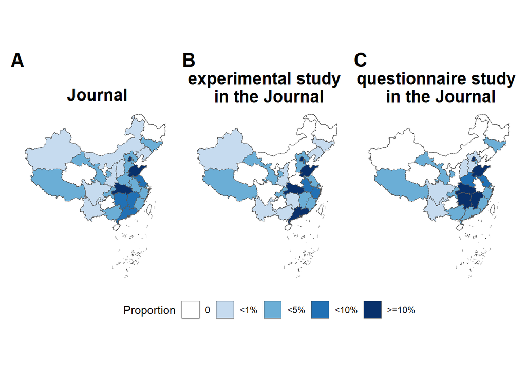

```r
## Journal
SupplH2_Fig_region_general <- ggplot() +
  geom_sf(data = China_province_region, fill = NA, color = "gray60", linewidth = 0.3) +
  geom_sf(data = China_line, fill = NA, color = "gray60", linewidth = 0.3) +
  geom_sf(data = SupplH1_studytype_map,aes(fill = factor(`Journal`)))+
  coord_sf(crs = aeqd_crs, xlim = c(-2700, 2400),
            ylim = c(-3700, 2400),
            expand = FALSE) +
  scale_fill_manual(values = my_blues,
                    breaks = c("0","1","2", "3", "4"),
                    labels = c("0", "<1%","<5%", "<10%",">=10%"),
                    name = "Proportion",
                    drop = FALSE)+
  theme_bw()+
  ggtitle("Journal")+
  theme(panel.border = element_blank(),
        panel.grid = element_blank(),
        axis.text = element_blank(),
        axis.ticks = element_blank(),
        plot.title = element_text(color = "black",size = 16,
                                  face = "bold",vjust = 0.1, hjust = 0.5),
        legend.position = "none")


## Journal experi
SupplH2_Fig_Journal_experi_region <- ggplot() +
  geom_sf(data = China_province_region, fill = NA, color = "gray60", linewidth = 0.3) +
  geom_sf(data = China_line, fill = NA, color = "gray60", linewidth = 0.3) +
  geom_sf(data = SupplH1_studytype_map,aes(fill = factor(`experimental study in the Journal`)))+
  coord_sf(crs = aeqd_crs, xlim = c(-2700, 2400),
            ylim = c(-3700, 2400),
            expand = FALSE) +
  scale_fill_manual(values = my_blues,
                    breaks = c("0","1","2", "3", "4"),
                    labels = c("0", "<1%","<5%", "<10%",">=10%"),
                    name = "Proportion",
                    drop = FALSE)+
  theme_bw()+
  ggtitle("experimental study  \nin the Journal")+
  theme(panel.border = element_blank(),
        panel.grid = element_blank(),
        axis.text = element_blank(),
        axis.ticks = element_blank(),
        plot.title = element_text(color = "black",size = 16,
                                  face = "bold",vjust = 0.1, hjust = 0.5),
        legend.position = "bottom")


## questionaire
SupplH2_Fig_Journal_questionaire_region <- ggplot() +
  geom_sf(data = China_province_region, fill = NA, color = "gray60", linewidth = 0.3) +
  geom_sf(data = China_line, fill = NA, color = "gray60", linewidth = 0.3) +
  geom_sf(data = SupplH1_studytype_map,aes(fill = factor(`questionnaire study in the Journal`)))+
  coord_sf(crs = aeqd_crs, xlim = c(-2700, 2400),
            ylim = c(-3700, 2400),
            expand = FALSE) +
  scale_fill_manual(values = my_blues,
                    breaks = c("0","1","2", "3", "4"),
                    labels = c("0", "<1%","<5%", "<10%",">=10%"),
                    name = "Proportion",
                    drop = FALSE)+
  theme_bw()+
  ggtitle("questionnaire study  \nin the Journal")+
  theme(panel.border = element_blank(),
        panel.grid = element_blank(),
        axis.text = element_blank(),
        axis.ticks = element_blank(),
        plot.title = element_text(color = "black",size = 16,
                                  face = "bold",vjust = 0.1, hjust = 0.5),
        legend.position = "none")


SupplH2_Fig_region_studytype <- SupplH2_Fig_region_general + SupplH2_Fig_Journal_experi_region + SupplH2_Fig_Journal_questionaire_region +
  plot_annotation(tag_levels = 'A') & theme(plot.tag = element_text(size = 18, face = "bold"))


ggsave(here("3_Data_Analysis","3_2_image","SupplH2_Fig_region_studytype.pdf"), SupplH2_Fig_region_studytype, device = "pdf", width=10, height = 6)

ggsave(here("3_Data_Analysis","3_2_image","SupplH2_Fig_region_studytype.png"), SupplH2_Fig_region_studytype, device = "png", width=10, height = 6, dpi = 600)

SupplH2_Fig_region_studytype
```

We also try to calculate the Spearman’s correlation between Journal region and SHANGHAI RANKING

```r
## psy2021
ShanghaiRanking_psy2021_provinceRank <- ShanghaiRanking_psy2021 %>%
  dplyr::rename(Region = 4,Rank = 1) %>%
  dplyr::group_by(Region) %>%
  dplyr::slice(1) %>%
  dplyr::ungroup() %>%
  dplyr::arrange(Rank) %>%
  dplyr::mutate(psy2021 = 1:21) %>%    ## give a rank num
  dplyr::select(Region,psy2021)

## applied psy
ShanghaiRanking_appliedpsy2021_provinceRank <- ShanghaiRanking_appliedpsy2021 %>%
  dplyr::rename(Region = 4,Rank = 1) %>%
  dplyr::group_by(Region) %>%
  dplyr::slice(1) %>%
  dplyr::ungroup() %>%
  dplyr::arrange(Rank) %>%
  dplyr::mutate(Appliedpsy2021 = 1:29) %>%
  dplyr::select(Region,Appliedpsy2021)

## Journal region
Journal_region_ShanghaiRanking <- Journal_region_general_tab2 %>%
  dplyr::arrange(desc(n)) %>%
  dplyr::mutate(Journal = 1:27) %>%
  dplyr::select(Region,Journal)


## create province name data
China_province <- data.frame(Region = c("新疆","西藏","甘肃","青海","内蒙古",
                    "宁夏","四川","重庆","陕西","贵州","云南",
                    "北京","山西","河北","河南","湖北","湖南",
                    "广西","广东","香港","澳门","台湾","海南",
                    "黑龙江","吉林","辽宁","天津","山东","江苏",
                    "安徽","上海","浙江","江西","福建"))

## psy merge data

Region_psy_cordata <- left_join(China_province,ShanghaiRanking_psy2021_provinceRank,by = "Region") %>%
  left_join(Journal_region_ShanghaiRanking,by = "Region")


## applied psy merge data
Region_appliedpsy_cordata <- left_join(China_province,ShanghaiRanking_appliedpsy2021_provinceRank,by = "Region") %>%
  left_join(Journal_region_ShanghaiRanking,by = "Region")
```

spearman relation

```r
## psy
BF_psy <- Region_psy_cordata %>%
correlation(select = "psy2021",
            select2 = "Journal",
            method = "spearman",
            bayesian = TRUE)

BF_psy
```

```
## # Correlation Matrix (spearman-method)
##
## Parameter1 | Parameter2 |  rho |        95% CI |     pd | % in ROPE
## -------------------------------------------------------------------
## psy2021    |    Journal | 0.34 | [-0.02, 0.66] | 95.90% |     9.15%
##
## Parameter1 |         Prior |   BF
## ---------------------------------
## psy2021    | Beta (3 +- 3) | 2.13
##
## Observations: 20
```

```r
log(BF_psy$BF)
```

```
## [1] 0.7538843
```

```r
## applied psy
BF_appliedpsy <- Region_appliedpsy_cordata %>%
  correlation(select = "Appliedpsy2021",
              select2 = "Journal",
              method = "spearman",
              bayesian =TRUE)

BF_appliedpsy
```

```
## # Correlation Matrix (spearman-method)
##
## Parameter1     | Parameter2 |  rho |       95% CI |       pd | % in ROPE
## ------------------------------------------------------------------------
## Appliedpsy2021 |    Journal | 0.49 | [0.19, 0.75] | 99.72%** |     1.45%
##
## Parameter1     |         Prior |      BF
## ----------------------------------------
## Appliedpsy2021 | Beta (3 +- 3) | 19.79**
##
## Observations: 25
```

```r
log(BF_appliedpsy$BF)
```

```
## [1] 2.985203
```

## Bibliometric Analysis

BTS data

```r
## split keyword
BTS_keywords_split_rows <- BTS_keywords %>%
  dplyr::filter(!is.na(Article_Keywords)) %>%
  tidyr::separate_rows(Article_Keywords,sep = ";") %>%
  dplyr::mutate(Article_Keywords =  str_to_title(Article_Keywords),
                Article_Keywords = ifelse(Article_Keywords == "Covid-19", "COVID-19",
                                          Article_Keywords))


## tab
BTS_keywords_tab <- BTS_keywords_split_rows %>%
  dplyr::group_by(Article_Keywords) %>%
  dplyr::summarise(n = n()) %>%
  dplyr::mutate(cate = factor(n))
```

BTS wordcloud

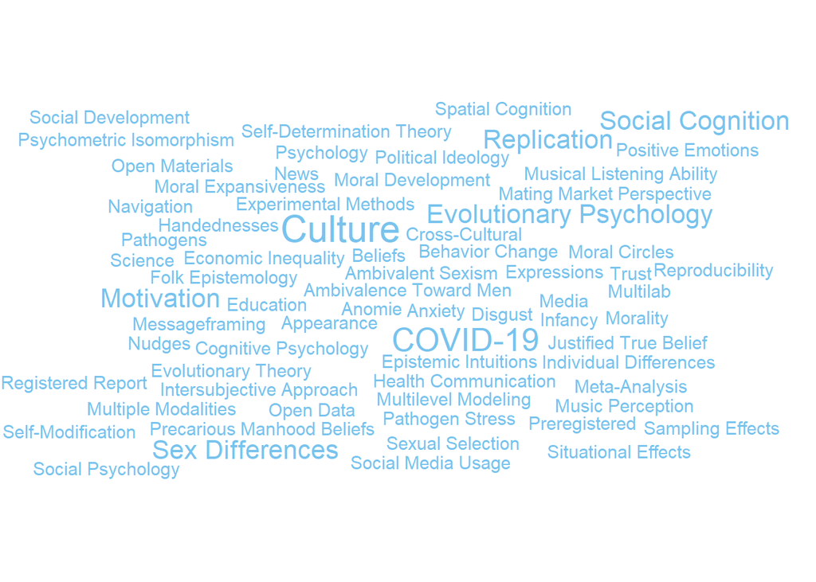

```r
Suppl_Fig_BTS_wordcloud <- BTS_keywords_tab %>%
  ggplot(aes(label = Article_Keywords,
             size = n)) +
  geom_text_wordcloud(shape = "square",
                      alpha = 0.8,
                      color = "#56B4E9") +
  scale_size_area(max_size = 8) +
  theme_void()


Suppl_Fig_BTS_wordcloud
```

Journal data

```r
Journal_keywords2 <- Journal_keywords %>%
  dplyr::select(Article_IDs,Article_Title,`Keyword-关键词`,`Year-年`) %>%
  dplyr::rename(Keywords = 3 , Year = 4) %>%
  tidyr::separate_rows(3, sep = "[;,.\\s|]+") %>%
  group_by(Keywords) %>%
  summarise(tab = n(), .groups = "drop") %>%
  arrange(desc(tab))


## filter 69
## total
Journal_keywords_tab69 <- Journal_keywords2 %>%
  arrange(desc(tab)) %>%
  select(Keywords,tab) %>%
  slice(1:84)
```

Journal wordcloud

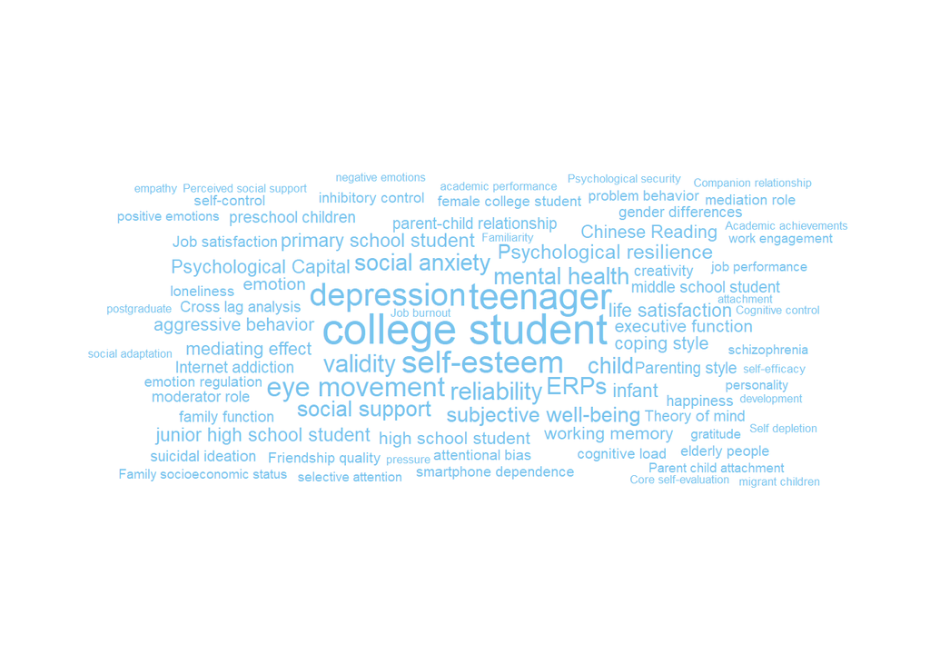

```r
## save data and convert Chinese keywords into English keywords

# writexl::write_xlsx(Journal_keywords3,"Journal_keywords3.xlsx")
# "Journal_keywords3" and "Journal_keywords_translation" are the same file; the latter is the translated version.

Journal_keywords4 <-  Journal_keywords_translation %>%
  dplyr::group_by(en) %>%
  dplyr::mutate(tab = sum(tab),
                cate = factor(tab)) %>%
  dplyr::slice(1) %>%
  dplyr::arrange(desc(tab))


## plot
Suppl_Fig_Journal_wordcloud <- Journal_keywords4 %>%
  ggplot(aes(label = en,
             size = tab,
             color = cate)) +
  geom_text_wordcloud(shape = "square",
                      alpha = 0.8,
                      color = "#56B4E9") +
  scale_size_area(max_size = 8) +
  theme_void()

Suppl_Fig_Journal_wordcloud
```

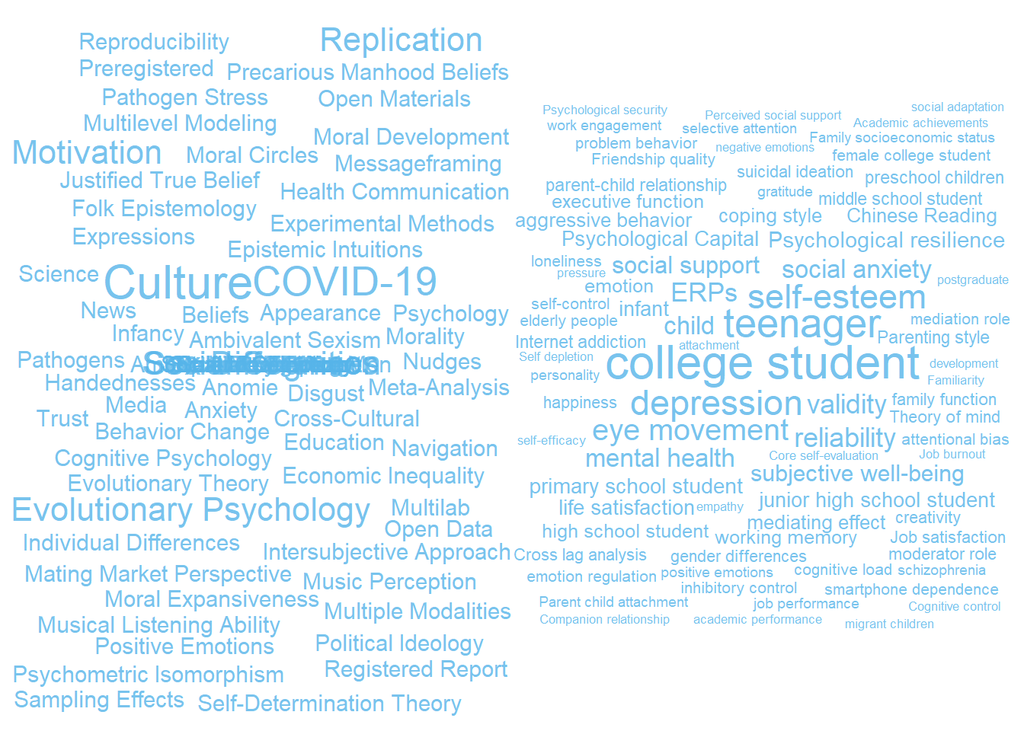

```r
Suppl_Fig_Wordcloud <- Suppl_Fig_BTS_wordcloud + Suppl_Fig_Journal_wordcloud

Suppl_Fig_Wordcloud
```

```r
ggsave(here("3_Data_Analysis","3_2_image","Suppl_Fig_Wordcloud.pdf")
,Suppl_Fig_Wordcloud, device = "pdf", width=18, height = 9)

ggsave(here("3_Data_Analysis","3_2_image","Suppl_Fig_Wordcloud.png")
,Suppl_Fig_Wordcloud, device = "png", width=18, height = 9)
```

## H3 exloration analysis

I continued to use the same steps to divide age into four age group.

```r
Sim_Sens_mult_age_four <- function(Mean1, diff_age, SD1, sample_N=Sample_Size){


  ageData_age_four <-  c(pnorm(17, mean = Mean1, sd = SD1) * sample_N,
                          (pnorm(40, mean = Mean1, sd = SD1) - pnorm(17, mean = Mean1, sd = SD1)) *sample_N,
                          (pnorm(60, mean = Mean1, sd = SD1) - pnorm(40, mean = Mean1, sd = SD1)) *sample_N,
                          (1 - pnorm(60, mean = Mean1, sd = SD1)) * sample_N)


  # create a dataframe with ageData_Fourage
  Sim_age_four_df <- setNames(data.frame(matrix(ncol = 2, nrow = 4)), c("ageBins", "sim1"))
  Sim_age_four_df$ageBins <- c("<=17", "18~40", "41~60",">=61")
  Sim_age_four_df$sim1[1:4] <- ageData_age_four


  return(Sim_age_four_df)
}
```

process and transform Journal data

```r
Journal_age_four_general <- Journal_age2 %>%
  dplyr::filter(Target_Population_N != 1)


Sim_Journal_age_four_general <- lapply(1:nrow(Journal_age_four_general),function(i){

  Sim_Sens_mult_age_four(Mean1 = Journal_age_four_general$M_age[i],
                diff_age = 0,
                SD1 = Journal_age_four_general$SD_age[i],
                sample_N = Journal_age_four_general$Sample_Size[i])

  })


Sim_Journal_age_four2_general <- do.call(rbind,Sim_Journal_age_four_general)


Sim_Journal_age_four3_general <- Sim_Journal_age_four2_general %>%
  dplyr::group_by(ageBins) %>%
  dplyr::summarise(sim1 = sum(sim1,na.rm = TRUE)) %>%
  dplyr::ungroup() %>%
  dplyr::mutate(ageBins =factor(ageBins,
                                levels = c("<=17","18~40", "41~60", ">=61")))


## Calculate the sample difference between the coded data and the simulated data
sum(Journal_age_four_general$Sample_Size)-sum(Sim_Journal_age_four3_general$sim1,na.rm = TRUE)
```

```
## [1] 0
```

process and transform BTS data

```r
BTS_age_four_list <- list()

for(i in seq_along(BTS)){

  BTS_name <- names(BTS)[i]

  if("Age" %in% names(BTS[[i]])){

    BTS_age <- BTS[[i]] %>%
      dplyr::filter(!is.na(Age) & !is.na(ISO3)) %>%
      dplyr::mutate(Age = as.numeric(Age)) %>%
      dplyr::select(Article_Id,Age,Target_Population,ISO3) %>%
      #dplyr::group_by(ISO3) %>%
      dplyr::mutate(ageBins = cut(Age,
                                breaks = c(0, 17.5, 40.5, 60.5, Inf),
                                labels = c("<=17","18~40", "41~60", ">=61"),
                                levels = c("<=17","18~40","41~60", ">=61")))


BTS_age_four_list[[BTS_name]] <- BTS_age

} else {

    cat(sprintf("Skipping '%s' because it does not contain a 'Age' column.\n", BTS_name))
  }
}
```

```
## Skipping 'BTS_Atari_et_al_2020' because it does not contain a 'Age' column.
```

```r
## merge data.frame in list
BTS_age_four <-  do.call(rbind,BTS_age_four_list)
```

combine data and trans data form for plot

```r
## filter > 30
BTS_age_four_allcountry_filter <-  BTS_age_four %>%
  dplyr::filter(Article_Id != "Lucca_et_al_2024") %>%  ## filter target population is a and 3
  dplyr::group_by(ISO3) %>%
  dplyr::summarise(n=n()) %>%
  dplyr::filter(n > 30) %>%
  dplyr::ungroup() %>%
  dplyr::pull(ISO3)


BTS_age_four_allcountry <- BTS_age_four %>%
  dplyr::filter(ISO3 %in% BTS_age_four_allcountry_filter) %>%
  dplyr::filter(ISO3 != "CHN") %>% ## drop Chinese data
  dplyr::group_by(ISO3,ageBins) %>%
  dplyr::summarise(n=n()) %>%
  dplyr::mutate(Proportion = n/sum(n)*100) %>%
  dplyr::ungroup()
```

```
## `summarise()` has regrouped the output.
## ℹ Summaries were computed grouped by ISO3 and ageBins.
## ℹ Output is grouped by ISO3.
## ℹ Use `summarise(.groups = "drop_last")` to silence this message.
## ℹ Use `summarise(.by = c(ISO3, ageBins))` for per-operation grouping
##   (`?dplyr::dplyr_by`) instead.
```

```r
## calculate total sum
BTS_age_four_allcountry_sum_prop <- BTS_age_four_allcountry %>%
  dplyr::group_by(ISO3) %>%
  dplyr::summarise(sum = sum(Proportion)) %>%
  dplyr::ungroup()


## Add Chinese data
BTS_age_four_CHN <- BTS_age_four %>%
  dplyr::filter(Article_Id != "Lucca_et_al_2024") %>%
  dplyr::filter(ISO3 == "CHN") %>%
  dplyr::group_by(ISO3,ageBins) %>%
  dplyr::summarise(n = n()) %>%
  dplyr::ungroup()
```

```
## `summarise()` has regrouped the output.
## ℹ Summaries were computed grouped by ISO3 and ageBins.
## ℹ Output is grouped by ISO3.
## ℹ Use `summarise(.groups = "drop_last")` to silence this message.
## ℹ Use `summarise(.by = c(ISO3, ageBins))` for per-operation grouping
##   (`?dplyr::dplyr_by`) instead.
```

```r
## combine CHN data
Journal_age_four <- Sim_Journal_age_four3_general %>%
  dplyr::mutate(ISO3 = "CHN") %>%
  dplyr::rename(n =sim1)


Journal_BTS_age_four_CHN <- bind_rows(BTS_age_four_CHN, Journal_age_four)


Journal_BTS_age_four_CHN2 <- Journal_BTS_age_four_CHN %>%
  dplyr::group_by(ageBins) %>%
  dplyr::summarise(n = sum(n)) %>%
  dplyr::ungroup() %>%
  dplyr::mutate(ISO3 = "CHN") %>%
  dplyr::mutate(Proportion = n/sum(n)*100)

sum(Journal_BTS_age_four_CHN2$Proportion)
```

```
## [1] 100
```

```r
## Combine data
H3_age_four <- dplyr::bind_rows(BTS_age_four_allcountry, Journal_BTS_age_four_CHN2)


# table(H3_PsyStages$ageBins)

## Set factor
H3_age_four_factor <- H3_age_four %>%
  dplyr::filter(ageBins == "18~40") %>%
  dplyr::arrange(Proportion) %>%
  dplyr::pull(ISO3)



## Process WEIRD
H3_age_four2 <- H3_age_four %>%
  dplyr::left_join(WEIRD, by = c("ISO3" = "iso3c")) %>%
  dplyr::mutate(WEIRD = ifelse(ISO3 == "XKX","WEIRD",WEIRD)) %>%
  dplyr::mutate(ISO3 = factor(ISO3, levels = H3_age_four_factor)) %>%
  dplyr::filter(!is.na(ageBins))


## 18~40 age
H3_age_four2 %>%
  dplyr::distinct(ISO3)
```

```
## # A tibble: 128 × 1
##    ISO3
##    <fct>
##  1 AGO
##  2 ALB
##  3 ARE
##  4 ARG
##  5 ARM
##  6 ATG
##  7 AUS
##  8 AUT
##  9 AZE
## 10 BEL
## # ℹ 118 more rows
```

```r
H3_age_four2_1840 <- H3_age_four2 %>%
  dplyr::filter(ageBins == "18~40") %>%
  dplyr::filter(Proportion > 60)   ## 124
```

plot

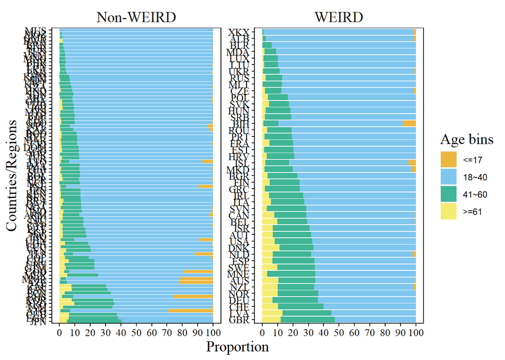

```r
SupplH3_Fig_age_four <- ggplot(H3_age_four2, aes(x=Proportion, y=ISO3, fill=ageBins)) +
  geom_col(alpha = .75)+
  labs(y="Countries/Regions",fill = "Age bins") +
  scale_fill_discrete(label=c("<=17", "18~40", "41~60",">=61")) +
  theme_classic()+
  #guides(y="axis_nested") +
  theme(legend.title = element_text(size = 15,family = "serif"),
        axis.title= element_text(size = 15,family = "serif"),
        axis.text = element_text(size = 10,family = "serif"),
        strip.text = element_text(size = 15,family = "serif"),
        strip.background = element_rect(fill = NA,color = NA),
        panel.border = element_rect(fill = NA,color = "black")) +
  scale_x_continuous(breaks = seq(0, 100, by = 10)) +
  facet_wrap(~ WEIRD, scales = "free",
             labeller = as_labeller(c("Non_WEIRD" = "Non-WEIRD", "WEIRD" = "WEIRD"))) +
  scale_fill_okabe_ito()
SupplH3_Fig_age_four
```

```r
ggsave(here("3_Data_Analysis","3_2_image","SupplH3_Fig_age_four.pdf"),
       SupplH3_Fig_age_four,device = "pdf", width=18, height = 18)

ggsave(here("3_Data_Analysis","3_2_image","SupplH3_Fig_age_four.png"),
       SupplH3_Fig_age_four,device = "png", width=18, height = 18, dpi = 600)
```